# Carnet Acces Information

## Interroger une base de données (accès à l'information)

*Importation des modules pandas et matplotlib.*</I>

```python
import pandas as pan
```

```python
%matplotlib inline
import matplotlib as mp
import matplotlib.pyplot as plt
```

*Afficher les nombres sans notation scientifiques.*</I>

```python
pan.set_option("display.float_format", lambda x : "%.2f" % x)
```

*Lecture du fichier csv avec le module panda.*</I>

```python
acces = pan.read_csv("ati.csv", low_memory=False)
```

*Affichage de notre fichier csv dans un tableau.*</I>

```python
acces
```

|  | year | month | request_number | summary_en | summary_fr | disposition | pages | owner_org | owner_org_title |
| --- | --- | --- | --- | --- | --- | --- | --- | --- | --- |
| 0 | 2016 | 3 | A-2015-00070 | Provide a copy of the Transitional Briefing Bo... | Fournir une copie du document d'information su... | Disclosed in part / Communication partielle | 563 | aafc-aac | Agriculture and Agri-Food Canada \| Agriculture... |
| 1 | 2017 | 5 | A-2016-00059 | All communications between the AgriMarketing P... | Toutes les communications entre le programme A... | Disclosed in part/\r\nCommunication partielle | 311 | aafc-aac | Agriculture and Agri-Food Canada \| Agriculture... |
| 2 | 2016 | 3 | A-2015-00059 | Copies of any and all briefing materials prep... | Tous les cahiers de breffage préparés à l'inte... | Disclosed in part / Communication partielle | 563 | aafc-aac | Agriculture and Agri-Food Canada \| Agriculture... |
| 3 | 2016 | 7 | A-2016-00076 | The amount of funding provided to National Far... | Le montant du financement octroyé au Conseil n... | No records exist / Aucun documents existant | 0 | aafc-aac | Agriculture and Agri-Food Canada \| Agriculture... |
| 4 | 2016 | 3 | A-2015-00113 | All records relating to a 2015-2016 outbreak ... | Tous les documents portant sur l'éclosion de l... | No records exist / Aucun document existant | 0 | aafc-aac | Agriculture and Agri-Food Canada \| Agriculture... |
| 5 | 2016 | 3 | A-2015-00109 | Any communications, since January, 2015, betwe... | Toute communication, depuis janvier 2015, entr... | Disclosed in part / Communication partielle | 7 | aafc-aac | Agriculture and Agri-Food Canada \| Agriculture... |
| 6 | 2016 | 3 | A-2015-00108 | Forensic audit report as described in Merx Sol... | Le rapport de vérification judiciaire tel que ... | All exempted / Tous exclus | 0 | aafc-aac | Agriculture and Agri-Food Canada \| Agriculture... |
| 7 | 2016 | 3 | A-2015-00107 | Pin-to-Pin messages between Pierre Corriveau a... | Tous les messages NIP à NIP entre Pierre Corri... | Disclosed in part / Communication partielle | 24 | aafc-aac | Agriculture and Agri-Food Canada \| Agriculture... |
| 8 | 2016 | 3 | A-2015-00082 | Policy briefing book for the new minister | Le cahier d'information sur les politiques à l... | Disclosed in part / Communication partielle | 563 | aafc-aac | Agriculture and Agri-Food Canada \| Agriculture... |
| 9 | 2016 | 3 | A-2015-00106 | Any communications on or instructions given to... | Toute communication ou directive donnée au min... | Disclosed in part / Communication partielle | 4 | aafc-aac | Agriculture and Agri-Food Canada \| Agriculture... |
| 10 | 2016 | 3 | A-2015-00100 | A list of briefing materials, notes or memos ... | Une liste des documents d'information, des not... | Disclosed in part / Communication partielle | 10 | aafc-aac | Agriculture and Agri-Food Canada \| Agriculture... |
| 11 | 2016 | 3 | A-2015-00098 | All information about which company was funded... | Toute l'information sur les entreprises qui on... | No records exist / Aucun document existant | 0 | aafc-aac | Agriculture and Agri-Food Canada \| Agriculture... |
| 12 | 2016 | 3 | A-2015-00085 | Copies of any briefing books or transition boo... | Une copie des cahiers de breffage ou de transi... | Disclosed in part / Communication partielle | 563 | aafc-aac | Agriculture and Agri-Food Canada \| Agriculture... |
| 13 | 2016 | 3 | A-2015-00084 | A copy of the briefing book/binder/notes prepa... | Une copie du cahier de breffage et de tout doc... | Disclosed in part / Communication partielle | 563 | aafc-aac | Agriculture and Agri-Food Canada \| Agriculture... |
| 14 | 2016 | 3 | A-2015-00063 | All briefing notes, memos, talking points, min... | Toutes les notes d'information, notes de servi... | Disclosed in part / Communication partielle | 47 | aafc-aac | Agriculture and Agri-Food Canada \| Agriculture... |
| 15 | 2016 | 3 | A-2015-00061 | Provide access to last available draft or copy... | Donner accès à la dernière ébauche ou copie du... | Disclosed in part / Communication partielle | 563 | aafc-aac | Agriculture and Agri-Food Canada \| Agriculture... |
| 16 | 2016 | 3 | A-2015-00058 | Copies of any briefing books or transition boo... | Une copie des cahiers de breffage ou de transi... | Disclosed in part / Communication partielle | 563 | aafc-aac | Agriculture and Agri-Food Canada \| Agriculture... |
| 17 | 2016 | 3 | A-2015-00057 | I would like to receive a copy of all briefing... | Je désire recevoir le/les livres de breffage e... | Disclosed in part / Communication partielle | 563 | aafc-aac | Agriculture and Agri-Food Canada \| Agriculture... |
| 18 | 2016 | 3 | A-2015-00052 | Records created by AAFC Programs Branch (Farm ... | Les dossiers créés par la Direction générale d... | Disclosed in part / Communication partielle | 359 | aafc-aac | Agriculture and Agri-Food Canada \| Agriculture... |
| 19 | 2016 | 3 | A-2014-00183 | Table 1: Projects Conducted With Neonicotinoid... | Tableau 1 : Projets réalisés avec des composé... | Disclosed in part / Communication partielle | 570 | aafc-aac | Agriculture and Agri-Food Canada \| Agriculture... |
| 20 | 2016 | 3 | A-2014-00182 | Table 1: Projects Conducted With Neonicotinoid... | Tableau 1 : Projets réalisés avec des composé... | Disclosed in part / Communication partielle | 570 | aafc-aac | Agriculture and Agri-Food Canada \| Agriculture... |
| 21 | 2016 | 3 | A-2014-00161 | Table 1: Projects Conducted With Neonicotinoid... | Tableau 1 : Projets réalisés avec des composé... | Disclosed in part / Communication partielle | 570 | aafc-aac | Agriculture and Agri-Food Canada \| Agriculture... |
| 22 | 2016 | 3 | A-2014-00160 | Table 1: Projects Conducted With Neonicotinoid... | Tableau 1 : Projets réalisés avec des composé... | Disclosed in part / Communication partielle | 570 | aafc-aac | Agriculture and Agri-Food Canada \| Agriculture... |
| 23 | 2016 | 7 | A-2016-00071 | The amount of funding provided to National Far... | Le montant du financement octroyé au Conseil n... | No records exist / Aucun documents existant | 0 | aafc-aac | Agriculture and Agri-Food Canada \| Agriculture... |
| 24 | 2017 | 7 | A-2017-00063 | Copy of the briefing note (#226947) UPDATE ON ... | Copie de la note d'information (# 226947) MISE... | Disclosed in part/\r\nCommunication partielle | 29 | aafc-aac | Agriculture and Agri-Food Canada \| Agriculture... |
| 25 | 2016 | 10 | A-2016-00121 | Please provide copies of the tobacco farming d... | Veuillez fournir des copies des estimations de... | Aucun document existant / No records exit | 0 | aafc-aac | Agriculture and Agri-Food Canada \| Agriculture... |
| 26 | 2016 | 4 | A-2016-0002 | Farm-level micro data solely for dairy, poultr... | Microdonnées uniquement sur les fermes laitièr... | All exempted/ tous exclus | 3000 | aafc-aac | Agriculture and Agri-Food Canada \| Agriculture... |
| 27 | 2016 | 4 | A-2015-00112 | Any damage assessments, executive memos, brief... | Tout document (évaluation des dommages, note à... | No records exist / Aucun document existant | 0 | aafc-aac | Agriculture and Agri-Food Canada \| Agriculture... |
| 28 | 2016 | 4 | A-2015-00103 | Provide information relating to the online que... | Information sur le logiciel d'interrogation en... | Disclosed in part / Communication partielle | 77 | aafc-aac | Agriculture and Agri-Food Canada \| Agriculture... |
| 29 | 2016 | 4 | A-2015-00101 | All information regarding quinoa production/im... | Toute l'information sur la production/l'import... | Disclosed in part / Communication partielle | 23 | aafc-aac | Agriculture and Agri-Food Canada \| Agriculture... |
| ... | ... | ... | ... | ... | ... | ... | ... | ... | ... |
| 28264 | 2017 | 5 | 2017-01 | Contracts between WDBA and Noel Desautels for ... | Contrats entre l’APWD (Autorité du Pont Windso... | Disclosed in part | 30 | wdba-apwd | Windsor-Detroit Bridge Authority \| Autorité du... |
| 28265 | 2016 | 10 | 2016-07 | “Copies of contracts awarded or other agreemen... | « Des copies de contrats attribués ou de tout ... | All disclosed | 1 | wdba-apwd | Windsor-Detroit Bridge Authority \| Autorité du... |
| 28266 | 2016 | 11 | 2016-20 | "The Request for Proposals (RFP) issued by the... | « La demande de propositions (DDP) émises par ... | All Exempted | 0 | wdba-apwd | Windsor-Detroit Bridge Authority \| Autorité du... |
| 28267 | 2017 | 2 | 2016-22 | \r\n"The monetary amount of contracts provided... | « La valeur monétaire des contrats soumis par ... | All disclosed | 2 | wdba-apwd | Windsor-Detroit Bridge Authority \| Autorité du... |
| 28268 | 2017 | 4 | 2016-21 | Since January 1, 2010, copies of 1) All contra... | Depuis le 1er janvier 2010, des copies de 1) t... | Disclosed in part | 989 | wdba-apwd | Windsor-Detroit Bridge Authority \| Autorité du... |
| 28269 | 2017 | 5 | 2016-12 | Any and all documents including drafts and ema... | Tous les documents, y compris les ébauches et ... | Disclosed in part | 64 | wdba-apwd | Windsor-Detroit Bridge Authority \| Autorité du... |
| 28270 | 2017 | 5 | 2016-14 | Any and all documents including drafts and ema... | Tous les documents, y compris les ébauches et ... | Disclosed in part | 39 | wdba-apwd | Windsor-Detroit Bridge Authority \| Autorité du... |
| 28271 | 2017 | 5 | 2016-15 | All meeting minutes including drafts for the I... | Tous les procès-verbaux des réunions, y compri... | All Exempted | 0 | wdba-apwd | Windsor-Detroit Bridge Authority \| Autorité du... |
| 28272 | 2017 | 11 | 2016-05 | All correspondence, including but not limited ... | Toutes les communications, y compris, sans s’y... | Disclosed in part | 349 | wdba-apwd | Windsor-Detroit Bridge Authority \| Autorité du... |
| 28273 | 2017 | 11 | 2016-13 | Any and all documents including drafts and ema... | Tous les documents, y compris les ébauches et ... | Disclosed in part | 306 | wdba-apwd | Windsor-Detroit Bridge Authority \| Autorité du... |
| 28274 | 2017 | 3 | A-2016-00009 | Records pertaining to Poly Culture Group | Documents portant sur le Poly Culture Group | Disclosed in part / Communication partielle | 122 | wd-deo | Western Economic Diversification Canada \| Dive... |
| 28275 | 2016 | 10 | A-2016-00003 | Relocation-related expenses for the Minister's... | Dépenses de réinstallation du personnel exonér... | No records exist /Aucun document n'existe | 0 | wd-deo | Western Economic Diversification Canada \| Dive... |
| 28276 | 2016 | 10 | A-2016-00006 | List of briefing materials provided to the hea... | Liste de documents d'information fournis au ch... | No records exist / Aucun document n'existe | 0 | wd-deo | Western Economic Diversification Canada \| Dive... |
| 28277 | 2016 | 10 | A-2016-00007 | List of briefing materials provided to the hea... | Liste de documents d'information fournis au ch... | All disclosed / Communication totale | 1 | wd-deo | Western Economic Diversification Canada \| Dive... |
| 28278 | 2016 | 11 | A-2016-00004 | Travel expenses claims for the Minister, Minis... | Réclamations des dépenses de voyage pour le mi... | Disclosed in part / Communication partielle | 666 | wd-deo | Western Economic Diversification Canada \| Dive... |
| 28279 | 2016 | 8 | A-2016-00002 | Records relating to Community Futures Mount Wa... | Dossiers relatifs à la Société d'aide au dével... | All disclosed / Communication totale | 22 | wd-deo | Western Economic Diversification Canada \| Dive... |
| 28280 | 2016 | 6 | A-2016-00001 | Records relating to the University of British ... | Dossiers relatifs au projet no 000013123 de l'... | Disclosed in part / Communication partielle | 625 | wd-deo | Western Economic Diversification Canada \| Dive... |
| 28281 | 2017 | 2 | A-2016-00011 | List of approved Canada 150 Community Infrastr... | Liste de projets approuvés dans le cadre du Pr... | Disclosed in part / Communication partielle | 96 | wd-deo | Western Economic Diversification Canada \| Dive... |
| 28282 | 2017 | 2 | A-2016-00013 | Carbon leakage in Alberta. | Fuite de carbone en Alberta. | Disclosed in part / Communication partielle | 20 | wd-deo | Western Economic Diversification Canada \| Dive... |
| 28283 | 2017 | 3 | A-2016-00014 | Canada 150 Community Infrastructure Program fu... | Demande de financement et entente de contribut... | All disclosed / Communication totale | 33 | wd-deo | Western Economic Diversification Canada \| Dive... |
| 28284 | 2017 | 1 | A-2016-00010 | Temporary help services call-ups against Stand... | Commandes subséquentes à l'offre à commandes n... | No records exist / Aucun document n'existe | 0 | wd-deo | Western Economic Diversification Canada \| Dive... |
| 28285 | 2017 | 4 | A-2016-00012 | Records relating/referring to Alberta's carbon... | Documents portant sur la taxe sur les émission... | Disclosed in part / Communication partielle | 113 | wd-deo | Western Economic Diversification Canada \| Dive... |
| 28286 | 2017 | 4 | A-2016-00015 | Canada 150 Community Infrastructure Program fu... | Demande de financement et entente de contribut... | Disclosed in part / Communication partielle | 38 | wd-deo | Western Economic Diversification Canada \| Dive... |
| 28287 | 2017 | 5 | A-2016-00016 | Documents pertaining to the Conseil de dévelop... | Documents se rapportant au Centre d’excellence... | Disclosed in part / Communication partielle | 113 | wd-deo | Western Economic Diversification Canada \| Dive... |
| 28288 | 2017 | 5 | A-2016-00017 | Documents pertaining to the Conseil de dévelop... | Documents se rapportant au Centre d’excellence... | Disclosed in part / Communication partielle | 38 | wd-deo | Western Economic Diversification Canada \| Dive... |
| 28289 | 2017 | 7 | A-2017-00002 | Records pertaining to the Gibsons Community Bu... | Documents se rapportant au projet Gibsons Comm... | Disclosed in part / Communication partielle | 44 | wd-deo | Western Economic Diversification Canada \| Dive... |
| 28290 | 2017 | 7 | A-2017-00003 | All records related to the 2017-2018 budgetary... | Tous les documents se rapportant à la présenta... | Disclosed in part / Communication partielle | 75 | wd-deo | Western Economic Diversification Canada \| Dive... |
| 28291 | 2017 | 7 | A-2017-00004 | Records related to the Conseil de développemen... | Documents se rapportant au Centre d’excellence... | Disclosed in part / Communication partielle | 79 | wd-deo | Western Economic Diversification Canada \| Dive... |
| 28292 | 2017 | 10 | A-2017-00005 | Records pertaining to One North, including any... | Dossiers se rapportant à One North, y compris ... | Disclosed in part / Communication partielle | 168 | wd-deo | Western Economic Diversification Canada \| Dive... |
| 28293 | 2017 | 12 | A-2017-00009 | Records related to hiring pools created as a r... | Documents relatifs à des bassins de candidats ... | Disclosed in part / Communication partielle | 6 | wd-deo | Western Economic Diversification Canada \| Dive... |

28294 rows × 9 columns

*Afficher le nombre de rangées et de colonnes que contient notre tableau.* </I>

```python
acces.shape
```

```
(28294, 9)
```

*Francisation des titres des colonnes du tableau.*</I>

```python
acces.columns
```

```
Index(['year', 'month', 'request_number', 'summary_en', 'summary_fr',
       'disposition', 'pages', 'owner_org', 'owner_org_title'],
      dtype='object')
```

```python
acces.columns = ['annee', 'mois', 'numerodelarequete', 'resume_ang', 'resume_fr',
       'disposition', 'pages', 'acronyme_org', 'titrecompletDelorganistion']
```

```python
acces.columns
```

```
Index(['annee', 'mois', 'numerodelarequete', 'resume_ang', 'resume_fr',
       'disposition', 'pages', 'acronyme_org', 'titrecompletDelorganistion'],
      dtype='object')
```

```python
acces
```

|  | annee | mois | numerodelarequete | resume_ang | resume_fr | disposition | pages | acronyme_org | titrecompletDelorganistion |
| --- | --- | --- | --- | --- | --- | --- | --- | --- | --- |
| 0 | 2016 | 3 | A-2015-00070 | Provide a copy of the Transitional Briefing Bo... | Fournir une copie du document d'information su... | Disclosed in part / Communication partielle | 563 | aafc-aac | Agriculture and Agri-Food Canada \| Agriculture... |
| 1 | 2017 | 5 | A-2016-00059 | All communications between the AgriMarketing P... | Toutes les communications entre le programme A... | Disclosed in part/\r\nCommunication partielle | 311 | aafc-aac | Agriculture and Agri-Food Canada \| Agriculture... |
| 2 | 2016 | 3 | A-2015-00059 | Copies of any and all briefing materials prep... | Tous les cahiers de breffage préparés à l'inte... | Disclosed in part / Communication partielle | 563 | aafc-aac | Agriculture and Agri-Food Canada \| Agriculture... |
| 3 | 2016 | 7 | A-2016-00076 | The amount of funding provided to National Far... | Le montant du financement octroyé au Conseil n... | No records exist / Aucun documents existant | 0 | aafc-aac | Agriculture and Agri-Food Canada \| Agriculture... |
| 4 | 2016 | 3 | A-2015-00113 | All records relating to a 2015-2016 outbreak ... | Tous les documents portant sur l'éclosion de l... | No records exist / Aucun document existant | 0 | aafc-aac | Agriculture and Agri-Food Canada \| Agriculture... |
| 5 | 2016 | 3 | A-2015-00109 | Any communications, since January, 2015, betwe... | Toute communication, depuis janvier 2015, entr... | Disclosed in part / Communication partielle | 7 | aafc-aac | Agriculture and Agri-Food Canada \| Agriculture... |
| 6 | 2016 | 3 | A-2015-00108 | Forensic audit report as described in Merx Sol... | Le rapport de vérification judiciaire tel que ... | All exempted / Tous exclus | 0 | aafc-aac | Agriculture and Agri-Food Canada \| Agriculture... |
| 7 | 2016 | 3 | A-2015-00107 | Pin-to-Pin messages between Pierre Corriveau a... | Tous les messages NIP à NIP entre Pierre Corri... | Disclosed in part / Communication partielle | 24 | aafc-aac | Agriculture and Agri-Food Canada \| Agriculture... |
| 8 | 2016 | 3 | A-2015-00082 | Policy briefing book for the new minister | Le cahier d'information sur les politiques à l... | Disclosed in part / Communication partielle | 563 | aafc-aac | Agriculture and Agri-Food Canada \| Agriculture... |
| 9 | 2016 | 3 | A-2015-00106 | Any communications on or instructions given to... | Toute communication ou directive donnée au min... | Disclosed in part / Communication partielle | 4 | aafc-aac | Agriculture and Agri-Food Canada \| Agriculture... |
| 10 | 2016 | 3 | A-2015-00100 | A list of briefing materials, notes or memos ... | Une liste des documents d'information, des not... | Disclosed in part / Communication partielle | 10 | aafc-aac | Agriculture and Agri-Food Canada \| Agriculture... |
| 11 | 2016 | 3 | A-2015-00098 | All information about which company was funded... | Toute l'information sur les entreprises qui on... | No records exist / Aucun document existant | 0 | aafc-aac | Agriculture and Agri-Food Canada \| Agriculture... |
| 12 | 2016 | 3 | A-2015-00085 | Copies of any briefing books or transition boo... | Une copie des cahiers de breffage ou de transi... | Disclosed in part / Communication partielle | 563 | aafc-aac | Agriculture and Agri-Food Canada \| Agriculture... |
| 13 | 2016 | 3 | A-2015-00084 | A copy of the briefing book/binder/notes prepa... | Une copie du cahier de breffage et de tout doc... | Disclosed in part / Communication partielle | 563 | aafc-aac | Agriculture and Agri-Food Canada \| Agriculture... |
| 14 | 2016 | 3 | A-2015-00063 | All briefing notes, memos, talking points, min... | Toutes les notes d'information, notes de servi... | Disclosed in part / Communication partielle | 47 | aafc-aac | Agriculture and Agri-Food Canada \| Agriculture... |
| 15 | 2016 | 3 | A-2015-00061 | Provide access to last available draft or copy... | Donner accès à la dernière ébauche ou copie du... | Disclosed in part / Communication partielle | 563 | aafc-aac | Agriculture and Agri-Food Canada \| Agriculture... |
| 16 | 2016 | 3 | A-2015-00058 | Copies of any briefing books or transition boo... | Une copie des cahiers de breffage ou de transi... | Disclosed in part / Communication partielle | 563 | aafc-aac | Agriculture and Agri-Food Canada \| Agriculture... |
| 17 | 2016 | 3 | A-2015-00057 | I would like to receive a copy of all briefing... | Je désire recevoir le/les livres de breffage e... | Disclosed in part / Communication partielle | 563 | aafc-aac | Agriculture and Agri-Food Canada \| Agriculture... |
| 18 | 2016 | 3 | A-2015-00052 | Records created by AAFC Programs Branch (Farm ... | Les dossiers créés par la Direction générale d... | Disclosed in part / Communication partielle | 359 | aafc-aac | Agriculture and Agri-Food Canada \| Agriculture... |
| 19 | 2016 | 3 | A-2014-00183 | Table 1: Projects Conducted With Neonicotinoid... | Tableau 1 : Projets réalisés avec des composé... | Disclosed in part / Communication partielle | 570 | aafc-aac | Agriculture and Agri-Food Canada \| Agriculture... |
| 20 | 2016 | 3 | A-2014-00182 | Table 1: Projects Conducted With Neonicotinoid... | Tableau 1 : Projets réalisés avec des composé... | Disclosed in part / Communication partielle | 570 | aafc-aac | Agriculture and Agri-Food Canada \| Agriculture... |
| 21 | 2016 | 3 | A-2014-00161 | Table 1: Projects Conducted With Neonicotinoid... | Tableau 1 : Projets réalisés avec des composé... | Disclosed in part / Communication partielle | 570 | aafc-aac | Agriculture and Agri-Food Canada \| Agriculture... |
| 22 | 2016 | 3 | A-2014-00160 | Table 1: Projects Conducted With Neonicotinoid... | Tableau 1 : Projets réalisés avec des composé... | Disclosed in part / Communication partielle | 570 | aafc-aac | Agriculture and Agri-Food Canada \| Agriculture... |
| 23 | 2016 | 7 | A-2016-00071 | The amount of funding provided to National Far... | Le montant du financement octroyé au Conseil n... | No records exist / Aucun documents existant | 0 | aafc-aac | Agriculture and Agri-Food Canada \| Agriculture... |
| 24 | 2017 | 7 | A-2017-00063 | Copy of the briefing note (#226947) UPDATE ON ... | Copie de la note d'information (# 226947) MISE... | Disclosed in part/\r\nCommunication partielle | 29 | aafc-aac | Agriculture and Agri-Food Canada \| Agriculture... |
| 25 | 2016 | 10 | A-2016-00121 | Please provide copies of the tobacco farming d... | Veuillez fournir des copies des estimations de... | Aucun document existant / No records exit | 0 | aafc-aac | Agriculture and Agri-Food Canada \| Agriculture... |
| 26 | 2016 | 4 | A-2016-0002 | Farm-level micro data solely for dairy, poultr... | Microdonnées uniquement sur les fermes laitièr... | All exempted/ tous exclus | 3000 | aafc-aac | Agriculture and Agri-Food Canada \| Agriculture... |
| 27 | 2016 | 4 | A-2015-00112 | Any damage assessments, executive memos, brief... | Tout document (évaluation des dommages, note à... | No records exist / Aucun document existant | 0 | aafc-aac | Agriculture and Agri-Food Canada \| Agriculture... |
| 28 | 2016 | 4 | A-2015-00103 | Provide information relating to the online que... | Information sur le logiciel d'interrogation en... | Disclosed in part / Communication partielle | 77 | aafc-aac | Agriculture and Agri-Food Canada \| Agriculture... |
| 29 | 2016 | 4 | A-2015-00101 | All information regarding quinoa production/im... | Toute l'information sur la production/l'import... | Disclosed in part / Communication partielle | 23 | aafc-aac | Agriculture and Agri-Food Canada \| Agriculture... |
| ... | ... | ... | ... | ... | ... | ... | ... | ... | ... |
| 28264 | 2017 | 5 | 2017-01 | Contracts between WDBA and Noel Desautels for ... | Contrats entre l’APWD (Autorité du Pont Windso... | Disclosed in part | 30 | wdba-apwd | Windsor-Detroit Bridge Authority \| Autorité du... |
| 28265 | 2016 | 10 | 2016-07 | “Copies of contracts awarded or other agreemen... | « Des copies de contrats attribués ou de tout ... | All disclosed | 1 | wdba-apwd | Windsor-Detroit Bridge Authority \| Autorité du... |
| 28266 | 2016 | 11 | 2016-20 | "The Request for Proposals (RFP) issued by the... | « La demande de propositions (DDP) émises par ... | All Exempted | 0 | wdba-apwd | Windsor-Detroit Bridge Authority \| Autorité du... |
| 28267 | 2017 | 2 | 2016-22 | \r\n"The monetary amount of contracts provided... | « La valeur monétaire des contrats soumis par ... | All disclosed | 2 | wdba-apwd | Windsor-Detroit Bridge Authority \| Autorité du... |
| 28268 | 2017 | 4 | 2016-21 | Since January 1, 2010, copies of 1) All contra... | Depuis le 1er janvier 2010, des copies de 1) t... | Disclosed in part | 989 | wdba-apwd | Windsor-Detroit Bridge Authority \| Autorité du... |
| 28269 | 2017 | 5 | 2016-12 | Any and all documents including drafts and ema... | Tous les documents, y compris les ébauches et ... | Disclosed in part | 64 | wdba-apwd | Windsor-Detroit Bridge Authority \| Autorité du... |
| 28270 | 2017 | 5 | 2016-14 | Any and all documents including drafts and ema... | Tous les documents, y compris les ébauches et ... | Disclosed in part | 39 | wdba-apwd | Windsor-Detroit Bridge Authority \| Autorité du... |
| 28271 | 2017 | 5 | 2016-15 | All meeting minutes including drafts for the I... | Tous les procès-verbaux des réunions, y compri... | All Exempted | 0 | wdba-apwd | Windsor-Detroit Bridge Authority \| Autorité du... |
| 28272 | 2017 | 11 | 2016-05 | All correspondence, including but not limited ... | Toutes les communications, y compris, sans s’y... | Disclosed in part | 349 | wdba-apwd | Windsor-Detroit Bridge Authority \| Autorité du... |
| 28273 | 2017 | 11 | 2016-13 | Any and all documents including drafts and ema... | Tous les documents, y compris les ébauches et ... | Disclosed in part | 306 | wdba-apwd | Windsor-Detroit Bridge Authority \| Autorité du... |
| 28274 | 2017 | 3 | A-2016-00009 | Records pertaining to Poly Culture Group | Documents portant sur le Poly Culture Group | Disclosed in part / Communication partielle | 122 | wd-deo | Western Economic Diversification Canada \| Dive... |
| 28275 | 2016 | 10 | A-2016-00003 | Relocation-related expenses for the Minister's... | Dépenses de réinstallation du personnel exonér... | No records exist /Aucun document n'existe | 0 | wd-deo | Western Economic Diversification Canada \| Dive... |
| 28276 | 2016 | 10 | A-2016-00006 | List of briefing materials provided to the hea... | Liste de documents d'information fournis au ch... | No records exist / Aucun document n'existe | 0 | wd-deo | Western Economic Diversification Canada \| Dive... |
| 28277 | 2016 | 10 | A-2016-00007 | List of briefing materials provided to the hea... | Liste de documents d'information fournis au ch... | All disclosed / Communication totale | 1 | wd-deo | Western Economic Diversification Canada \| Dive... |
| 28278 | 2016 | 11 | A-2016-00004 | Travel expenses claims for the Minister, Minis... | Réclamations des dépenses de voyage pour le mi... | Disclosed in part / Communication partielle | 666 | wd-deo | Western Economic Diversification Canada \| Dive... |
| 28279 | 2016 | 8 | A-2016-00002 | Records relating to Community Futures Mount Wa... | Dossiers relatifs à la Société d'aide au dével... | All disclosed / Communication totale | 22 | wd-deo | Western Economic Diversification Canada \| Dive... |
| 28280 | 2016 | 6 | A-2016-00001 | Records relating to the University of British ... | Dossiers relatifs au projet no 000013123 de l'... | Disclosed in part / Communication partielle | 625 | wd-deo | Western Economic Diversification Canada \| Dive... |
| 28281 | 2017 | 2 | A-2016-00011 | List of approved Canada 150 Community Infrastr... | Liste de projets approuvés dans le cadre du Pr... | Disclosed in part / Communication partielle | 96 | wd-deo | Western Economic Diversification Canada \| Dive... |
| 28282 | 2017 | 2 | A-2016-00013 | Carbon leakage in Alberta. | Fuite de carbone en Alberta. | Disclosed in part / Communication partielle | 20 | wd-deo | Western Economic Diversification Canada \| Dive... |
| 28283 | 2017 | 3 | A-2016-00014 | Canada 150 Community Infrastructure Program fu... | Demande de financement et entente de contribut... | All disclosed / Communication totale | 33 | wd-deo | Western Economic Diversification Canada \| Dive... |
| 28284 | 2017 | 1 | A-2016-00010 | Temporary help services call-ups against Stand... | Commandes subséquentes à l'offre à commandes n... | No records exist / Aucun document n'existe | 0 | wd-deo | Western Economic Diversification Canada \| Dive... |
| 28285 | 2017 | 4 | A-2016-00012 | Records relating/referring to Alberta's carbon... | Documents portant sur la taxe sur les émission... | Disclosed in part / Communication partielle | 113 | wd-deo | Western Economic Diversification Canada \| Dive... |
| 28286 | 2017 | 4 | A-2016-00015 | Canada 150 Community Infrastructure Program fu... | Demande de financement et entente de contribut... | Disclosed in part / Communication partielle | 38 | wd-deo | Western Economic Diversification Canada \| Dive... |
| 28287 | 2017 | 5 | A-2016-00016 | Documents pertaining to the Conseil de dévelop... | Documents se rapportant au Centre d’excellence... | Disclosed in part / Communication partielle | 113 | wd-deo | Western Economic Diversification Canada \| Dive... |
| 28288 | 2017 | 5 | A-2016-00017 | Documents pertaining to the Conseil de dévelop... | Documents se rapportant au Centre d’excellence... | Disclosed in part / Communication partielle | 38 | wd-deo | Western Economic Diversification Canada \| Dive... |
| 28289 | 2017 | 7 | A-2017-00002 | Records pertaining to the Gibsons Community Bu... | Documents se rapportant au projet Gibsons Comm... | Disclosed in part / Communication partielle | 44 | wd-deo | Western Economic Diversification Canada \| Dive... |
| 28290 | 2017 | 7 | A-2017-00003 | All records related to the 2017-2018 budgetary... | Tous les documents se rapportant à la présenta... | Disclosed in part / Communication partielle | 75 | wd-deo | Western Economic Diversification Canada \| Dive... |
| 28291 | 2017 | 7 | A-2017-00004 | Records related to the Conseil de développemen... | Documents se rapportant au Centre d’excellence... | Disclosed in part / Communication partielle | 79 | wd-deo | Western Economic Diversification Canada \| Dive... |
| 28292 | 2017 | 10 | A-2017-00005 | Records pertaining to One North, including any... | Dossiers se rapportant à One North, y compris ... | Disclosed in part / Communication partielle | 168 | wd-deo | Western Economic Diversification Canada \| Dive... |
| 28293 | 2017 | 12 | A-2017-00009 | Records related to hiring pools created as a r... | Documents relatifs à des bassins de candidats ... | Disclosed in part / Communication partielle | 6 | wd-deo | Western Economic Diversification Canada \| Dive... |

28294 rows × 9 columns

*Afficher les types de variables qui constituent notre tableau.*</I>

```python
acces.dtypes
```

```
annee                          int64
mois                           int64
numerodelarequete             object
resume_ang                    object
resume_fr                     object
disposition                   object
pages                          int64
acronyme_org                  object
titrecompletDelorganistion    object
dtype: object
```

*Affichage du nombre de demandes par année.*</I>

```python
acces.annee.value_counts()
```

```
2017    14284
2016    13275
2018      735
Name: annee, dtype: int64
```

*Affichage des différentes organisations qui ont reçu des demandes d'accès à l'information.*</I>

```python
acces.titrecompletDelorganistion.value_counts()
```

```
Global Affairs Canada | Affaires mondiales Canada                                                                                                                1799
National Defence | Défense nationale                                                                                                                             1703
Employment and Social Development Canada | Emploi et Développement social Canada                                                                                 1538
Innovation, Science and Economic Development Canada | Innovation, Sciences et Développement économique Canada                                                    1395
Immigration, Refugees and Citizenship Canada | Immigration, Réfugiés et Citoyenneté Canada                                                                       1394
Privy Council Office | Bureau du Conseil privé                                                                                                                   1233
Natural Resources Canada | Ressources naturelles Canada                                                                                                          1187
Department of Finance Canada | Ministère des Finances Canada                                                                                                     1181
Library and Archives Canada | Bibliothèque et Archives Canada                                                                                                    1010
Health Canada | Santé Canada                                                                                                                                      975
Canada Revenue Agency | Agence du revenu du Canada                                                                                                                910
Canada Border Services Agency | Agence des services frontaliers du Canada                                                                                         857
Transport Canada | Transports Canada                                                                                                                              830
Department of Justice | Ministère de la Justice                                                                                                                   769
Environment and Climate Change Canada | Environnement et Changement climatique Canada                                                                             706
Canadian Heritage | Patrimoine canadien                                                                                                                           695
Indigenous and Northern Affairs Canada | Affaires autochtones et du Nord Canada                                                                                   676
Public Safety Canada | Sécurité publique Canada                                                                                                                   675
Treasury Board of Canada Secretariat | Secrétariat du Conseil du Trésor du Canada                                                                                 649
Fisheries and Oceans Canada | Pêches et Océans Canada                                                                                                             645
Royal Canadian Mounted Police | Gendarmerie royale du Canada                                                                                                      579
Public Services and Procurement Canada | Services publics et Approvisionnement Canada                                                                             557
Canadian Food Inspection Agency | Agence canadienne d'inspection des aliments                                                                                     554
Parks Canada | Parcs Canada                                                                                                                                       524
Veterans Affairs Canada | Anciens Combattants Canada                                                                                                              457
Canadian Nuclear Safety Commission | Commission canadienne de sûreté nucléaire                                                                                    364
Agriculture and Agri-Food Canada | Agriculture et Agroalimentaire Canada                                                                                          343
```

[output cut: 35 more lines]

**Question 1:** *Combien de demandes d'accès à l'information ont été faites pour le ministère de la Défense nationale et combien de ces demandes n'avaient aucun document à fournir et combien avaient une communication totale?*

*Recherche des demandes concernant la Défense nationale sur l'ensemble total des demandes du fichier.*</I>

```python
Defense = acces.titrecompletDelorganistion == "National Defence | Défense nationale"
acces[Defense]
```

|  | annee | mois | numerodelarequete | resume_ang | resume_fr | disposition | pages | acronyme_org | titrecompletDelorganistion |
| --- | --- | --- | --- | --- | --- | --- | --- | --- | --- |
| 8992 | 2016 | 10 | A-2016-00992 | MND2016-1085651, on the RMC | MND2016-1085651, sur le CMR | All disclosed / Communication totale | 7 | dnd-mdn | National Defence \| Défense nationale |
| 8993 | 2017 | 9 | A-2016-01039 | DM2015-1013130 - Op Reassurance | DM2015-1013130 - Op REASSURANCE | All disclosed / Communication complète | 16 | dnd-mdn | National Defence \| Défense nationale |
| 8994 | 2016 | 12 | A-2016-00480 | All records contained in A-2016-00352 | Tous les documents du dossier A-2016-00352. | Disclosed in part / Communication partielle | 6 | dnd-mdn | National Defence \| Défense nationale |
| 8995 | 2016 | 8 | A-2016-00778 | All information contained in request A-2016-00209 | Tous les renseignements dans la demande A-2016... | Disclosed in part / Communication partielle | 0 | dnd-mdn | National Defence \| Défense nationale |
| 8996 | 2017 | 9 | A-2017-00093 | Personal information of a named individual | Les renseignements personnels d'une personne n... | Disclosed in part / Communication partielle | 2 | dnd-mdn | National Defence \| Défense nationale |
| 8997 | 2016 | 7 | A-2016-00444 | CMP2016-1060557 BRIEFING NOTE FOR MND | CMP2016_x001E_1060557 NOTE D’INFORMATION À L’I... | All disclosed / Communication totale | 6 | dnd-mdn | National Defence \| Défense nationale |
| 8998 | 2016 | 12 | A-2016-01375 | RCAF2016-107588, on engine considerations (sam... | RCAF2016-107588, sur les considérations du mot... | All disclosed / Communication totale | 4 | dnd-mdn | National Defence \| Défense nationale |
| 8999 | 2016 | 7 | A-2016-00446 | MND2016-1064661 5 WING GOOSE BAY - OVERVIEW AN... | MND2016_x001E_1064661, 5 ESCADRE GOOSE BAY – A... | All disclosed / Communication totale | 3 | dnd-mdn | National Defence \| Défense nationale |
| 9000 | 2016 | 4 | A-2015-02105 | List of bonuses paid to executives from 2010 t... | Une liste des bonis versés à des hauts dirigea... | Does not exist / Aucun document existe | 0 | dnd-mdn | National Defence \| Défense nationale |
| 9001 | 2016 | 4 | A-2015-01966 | Briefing note Docket # DM2015-1044632 06/10/20... | Notes d'information du 6 octobre 2015, registr... | All disclosed / Communication totale | 3 | dnd-mdn | National Defence \| Défense nationale |
| 9002 | 2016 | 4 | A-2015-02109 | Canadian Forces Grievance Authority For decisi... | Autorité des griefs des Forces canadiennes pou... | Disclosed in part / Communication partielle | 1 | dnd-mdn | National Defence \| Défense nationale |
| 9003 | 2016 | 3 | A-2015-01593 | A list of all briefing notes submitted to the ... | Liste de toutes les notes d’information présen... | Disclosed in part / Communication Partielle | 3 | dnd-mdn | National Defence \| Défense nationale |
| 9004 | 2016 | 12 | A-2016-01345 | POL2016-1072860 - PROPOSAL TO AFFILIATE AOPS W... | POL2016-1072860 - PROPOSITION D'AFFILIER LES N... | Nothing disclosed (exemption) / Tous exempté | 0 | dnd-mdn | National Defence \| Défense nationale |
| 9005 | 2016 | 12 | A-2016-01346 | RS2016-1080805 - BRIEFING PACKAGE - AUDITOR GE... | RS2016-1080805 - TROUSSE D'INFORMATION - VÉRIF... | All disclosed / Communication totale | 18 | dnd-mdn | National Defence \| Défense nationale |
| 9006 | 2017 | 1 | A-2016-01220 | DM2016-1077065 - PUBLIC SERVICE COMMISSION OF ... | DM2016-1077065 - SERVICE D'ENQUÊTES DE LA COMM... | Disclosed in part / Communication partielle | 89 | dnd-mdn | National Defence \| Défense nationale |
| 9007 | 2016 | 8 | A-2016-00520 | The "House Cards" prepared for the Minister fo... | Les « fiches parlementaires » préparées pour l... | Disclosed in part / Communication partielle | 1009 | dnd-mdn | National Defence \| Défense nationale |
| 9008 | 2017 | 11 | A-2017-00101 | Any records in any format regarding a Threat a... | NaN | Neither confirmed nor denied / Ni confirmée ni... | 0 | dnd-mdn | National Defence \| Défense nationale |
| 9009 | 2016 | 6 | A-2015-00309 | 85/386 - Mike Mobley. The discovery of Cosmos ... | 85/386 - Mike Mobley. La découverte du Cosmos ... | Nothing disclosed (exemption) / Tous exempté | 0 | dnd-mdn | National Defence \| Défense nationale |
| 9010 | 2016 | 5 | A-2015-00286 | 79/303 - CFB Edmonton. Op Morning Light; final... | 79/303 - BFC Edmonton. Op Morning Light; rappo... | Disclosed in part / Communication partielle | 339 | dnd-mdn | National Defence \| Défense nationale |
| 9011 | 2016 | 6 | A-2015-01048 | Briefing note DM2015-1006713 - Briefing On Var... | Note de briefing DM2015-1006713 – briefing sur... | Disclosed in part / Communication partielle | 3 | dnd-mdn | National Defence \| Défense nationale |
| 9012 | 2016 | 8 | A-2016-00521 | The "House Cards" prepared for the Minister fr... | Les « fiches parlementaires » préparées pour l... | Disclosed in part / Communication partielle | 847 | dnd-mdn | National Defence \| Défense nationale |
| 9013 | 2016 | 7 | A-2016-00449 | RCAF2016-1071755 STATUS OF RCAF UNMANNED AIRCR... | RCAF2016_x001E_1071755 ÉTAT DU PROGRAMME DU SY... | Disclosed in part / Communication partielle | 2 | dnd-mdn | National Defence \| Défense nationale |
| 9014 | 2016 | 3 | A-2015-00738 | Ministerial briefing note POL2015-1021705 26-M... | Note d’information ministérielle POL2015-10217... | Disclosed in part / Communication Partielle | 5 | dnd-mdn | National Defence \| Défense nationale |
| 9015 | 2016 | 3 | A-2015-01625 | All Criminal Intelligence Bulletins created be... | Tous les Criminal Intelligence Bulletins qui o... | Disclosed in part / Communication Partielle | 4 | dnd-mdn | National Defence \| Défense nationale |
| 9016 | 2016 | 3 | A-2013-01686 | The most recent copy in English and French of ... | La plus récente copie en anglais et en françai... | Disclosed in part / Communication Partielle | 500 | dnd-mdn | National Defence \| Défense nationale |
| 9017 | 2016 | 3 | A-2013-01429 | List of MP reports regarding consultation of c... | Liste des rapports de la PM sur le visionnemen... | Does not exist / Aucun Document Existe | 0 | dnd-mdn | National Defence \| Défense nationale |
| 9018 | 2016 | 3 | A-2013-00979 | All records providing an overview of the budge... | Tous les documents donnant une vue d’ensemble ... | Disclosed in part / Communication Partielle | 360 | dnd-mdn | National Defence \| Défense nationale |
| 9019 | 2016 | 3 | A-2013-01759 | All records related to CFDS refresh/update hel... | Tous les documents liés à la révision/mise à j... | Disclosed in part / Communication Partielle | 136 | dnd-mdn | National Defence \| Défense nationale |
| 9020 | 2016 | 3 | A-2013-01760 | All records related to CFDS refresh/update hel... | Tous les documents liés à la révision/mise à j... | Disclosed in part / Communication Partielle | 297 | dnd-mdn | National Defence \| Défense nationale |
| 9021 | 2016 | 3 | A-2013-01845 | Copies of all briefing notes and slide deck pr... | Copie de toutes les notes d’information et des... | Disclosed in part / Communication Partielle | 288 | dnd-mdn | National Defence \| Défense nationale |
| ... | ... | ... | ... | ... | ... | ... | ... | ... | ... |
| 10665 | 2017 | 9 | A-2017-00698 | Full report/reports into the incident/incident... | Le ou les rapports complets de l'incident ou d... | Does not exist / Aucun document existe | 0 | dnd-mdn | National Defence \| Défense nationale |
| 10666 | 2017 | 9 | A-2017-00755 | A list of all briefing notes prepared for the ... | Une liste de toutes les notes d’information pr... | Disclosed in part / Communication partielle | 1 | dnd-mdn | National Defence \| Défense nationale |
| 10667 | 2017 | 9 | A-2017-00756 | Briefing note: IRPDA | Note d’information : CIEAD | All excluded / Exclusion totale | 0 | dnd-mdn | National Defence \| Défense nationale |
| 10668 | 2017 | 9 | A-2017-00758 | Briefing Note: UN peacekeeping (follows A-201... | Note d’information : Opérations de maintien d... | Disclosed in part / Communication partielle | 9 | dnd-mdn | National Defence \| Défense nationale |
| 10669 | 2017 | 9 | A-2017-00760 | Report on use of administrative flight for bot... | Rapport sur l'utilisation des vols d'affaires ... | Disclosed in part / Communication partielle | 21 | dnd-mdn | National Defence \| Défense nationale |
| 10670 | 2017 | 9 | A-2017-00795 | Any and all references to "GPS spoofing" AND "... | Toutes les références au « sabotage du GPS » E... | Does not exist / Aucun document existe | 0 | dnd-mdn | National Defence \| Défense nationale |
| 10671 | 2017 | 9 | A-2017-00799 | Records, including briefing notes circulated a... | Les documents, y compris les notes d'informati... | Does not exist / Aucun document existe | 0 | dnd-mdn | National Defence \| Défense nationale |
| 10672 | 2017 | 9 | A-2017-00803 | Briefing note: Roadmap for Renewable Energy In... | Note d’information : Feuille de route pour des... | Disclosed in part / Communication partielle | 5 | dnd-mdn | National Defence \| Défense nationale |
| 10673 | 2017 | 9 | A-2017-00812 | Any studies, reports, emails or other correspo... | Toutes les études, tous les rapports, tous les... | Does not exist / Aucun document existe | 0 | dnd-mdn | National Defence \| Défense nationale |
| 10674 | 2017 | 9 | A-2017-00823 | Records showing how many members of the CAF ar... | Les documents indiquant combien de membres des... | Does not exist / Aucun document existe | 0 | dnd-mdn | National Defence \| Défense nationale |
| 10675 | 2017 | 9 | A-2017-00843 | All emails to and from the Deputy Minister con... | Tous les courriels destinés au sous-ministre o... | Does not exist / Aucun document existe | 0 | dnd-mdn | National Defence \| Défense nationale |
| 10676 | 2017 | 9 | A-2017-00846 | All records with the Minister of National Defe... | Tous les documents du ministre de la Défense n... | Does not exist / Aucun document existe | 0 | dnd-mdn | National Defence \| Défense nationale |
| 10677 | 2017 | 9 | A-2017-00847 | All audio recordings, video recordings and pho... | Tous les enregistrements audio, tous les enreg... | Does not exist / Aucun document existe | 0 | dnd-mdn | National Defence \| Défense nationale |
| 10678 | 2017 | 9 | A-2017-00848 | Flight logs and manifests for the August 2017 ... | Les journaux de bord et les manifestes pour le... | Disclosed in part / Communication partielle | 6 | dnd-mdn | National Defence \| Défense nationale |
| 10679 | 2017 | 9 | A-2017-00856 | Information onboard HMCS Annapolis, spring of ... | Les renseignements à bord du NCSM Annapolis, a... | All disclosed / Communication complète | 1 | dnd-mdn | National Defence \| Défense nationale |
| 10680 | 2017 | 9 | A-2017-00858 | Briefing note: Op Analysis | Note d’information : Op ANALYSIS | Disclosed in part / Communication partielle | 3 | dnd-mdn | National Defence \| Défense nationale |
| 10681 | 2017 | 9 | A-2017-00863 | Copy of the list of all investigations complet... | Copie de la liste de toutes les enquêtes termi... | Does not exist / Aucun document existe | 0 | dnd-mdn | National Defence \| Défense nationale |
| 10682 | 2017 | 9 | A-2017-00864 | List of all CANFORGEN messages, including the ... | La liste de tous les messages CANFORGEN, ce qu... | All disclosed / Communication complète | 10 | dnd-mdn | National Defence \| Défense nationale |
| 10683 | 2017 | 9 | A-2017-00865 | A list of all films that received Department o... | Une liste de tous les films qui ont reçu du fi... | Does not exist / Aucun document existe | 0 | dnd-mdn | National Defence \| Défense nationale |
| 10684 | 2017 | 9 | A-2017-00882 | Records showing promotion numbers from Master ... | Les documents qui indiquent le nombre de promo... | All disclosed / Communication complète | 4 | dnd-mdn | National Defence \| Défense nationale |
| 10685 | 2017 | 9 | A-2017-00888 | Excusals of CAF members for appointments on co... | Décharges des militaires des FAC pour les nomi... | All disclosed / Communication complète | 1 | dnd-mdn | National Defence \| Défense nationale |
| 10686 | 2017 | 9 | A-2017-00894 | Records from September 2016 to September 2017 ... | Les documents de septembre 2016 à septembre 20... | Does not exist / Aucun document existe | 0 | dnd-mdn | National Defence \| Défense nationale |
| 10687 | 2017 | 9 | A-2017-00900 | All memos, reports, deck presentations or othe... | Toutes les notes de service, tous les rapports... | Does not exist / Aucun document existe | 0 | dnd-mdn | National Defence \| Défense nationale |
| 10688 | 2017 | 9 | A-2017-00926 | All communication material that went to the el... | Tout le matériel de communication qui a été je... | Does not exist / Aucun document existe | 0 | dnd-mdn | National Defence \| Défense nationale |
| 10689 | 2017 | 9 | A-2017-00928 | All records about potential greenhouse gas emi... | Tous les documents au sujet des possibles émis... | Does not exist / Aucun document existe | 0 | dnd-mdn | National Defence \| Défense nationale |
| 10690 | 2017 | 9 | A-2017-00943 | All financial documents related to purchases o... | Tous les documents financiers relatifs à l’ach... | Does not exist / Aucun document existe | 0 | dnd-mdn | National Defence \| Défense nationale |
| 10691 | 2017 | 9 | A-2017-00944 | All financial documents related to purchases o... | Tous les documents financiers relatifs à l’ach... | Does not exist / Aucun document existe | 0 | dnd-mdn | National Defence \| Défense nationale |
| 10692 | 2017 | 9 | A-2017-00947 | All correspondence, memos, reports and draft r... | Toute la correspondance, toutes les notes de s... | Does not exist / Aucun document existe | 0 | dnd-mdn | National Defence \| Défense nationale |
| 10693 | 2017 | 9 | A-2017-00951 | Copy of all contracts with SCL GROUP LIMITED, ... | Copie de tous les contrats avec SCL GROUP LIMI... | Does not exist / Aucun document existe | 0 | dnd-mdn | National Defence \| Défense nationale |
| 10694 | 2017 | 9 | A-2017-00997 | I request a copy of the after-action report fo... | Je demande une copie du compte rendu après act... | Does not exist / Aucun document existe | 0 | dnd-mdn | National Defence \| Défense nationale |

1703 rows × 9 columns

*Affichage des différentes dispositions qui ont été prises concernant les demandes de la Défense nationale.*</I>

```python
acces[Defense].disposition.value_counts()
```

```
Disclosed in part / Communication partielle                876
Does not exist / Aucun document existe                     281
All disclosed / Communication totale                       274
Disclosed in part / Communication Partielle                 84
All disclosed / Communication complète                      76
Nothing disclosed (exemption) / Tous exempté                32
Does not exist / Aucun Document Existe                      27
Does not exist Aucun document existe                        26
All disclosed / Communication Totale                        11
Nothing disclosed (excluded) / Tous exclus                   7
All exempted / Exception totale                              3
Nothing disclosed (exemption) / Tous Exempté                 2
Neither confirmed nor denied / Ni confirmée ni infirmée      2
Does not exist/Aucun document existe                         1
All excluded / Exclusion totale                              1
Name: disposition, dtype: int64
```

*Aperçu des résumés en français des demandes concernant la Défense nationale.* </I>

```python
acces[Defense].resume_fr.value_counts()
```

```
Toutes les communications, y compris les courriels envoyés à et/ou par un membre des Forces canadiennes qui mentionnent un autre membre des Forces canadiennes, ou qui ont allusion à un membre, envoyés et/ou reçus du 1er mars 2015 au 1er décembre 2016.                                                 …
Rapport sur l’utilisation des vols d’affaires pour l’Airbus CC150 Polaris et l’avion Challenger par des personnalités de marque pendant le mois de décembre 2016.                                                                                                                                           …
Rapport sur l’utilisation des vols d’affaires pour l’Airbus CC150 Polaris et l’avion Challenger par des personnalités de marque pendant le mois de novembre 2016.                                                                                                                                           …
Liste ou feuille de travail des articles volés, endommagés ou perdus par le ministère de la Défense nationale et les Forces armées canadiennes pendant les années financières 2012-2013 et 2014-2015, ainsi qu’ils figurent dans les documents des Comptes publics.                                         …
Rapport sur l’utilisation de l’aéronef militaire Challenger pour des vols administratifs/militaires en décembre 2015.                                                                                                                                                                                       …
Renseignements sur un membre des Forces armées canadiennes.                                                                                                                                                                                                                                                 …
Rapport sur l’utilisation de l’aéronef militaire Challenger pour des vols administratifs/militaires en mars 2016.                                                                                                                                                                                           …
Une liste des titres et des registres de notes de synthèse, de notes de service et de rapports générés par ou pour le ministre ou le cabinet du ministre du 16 au 29 février 2016.                                                                                                                          …
Rapport sur l’utilisation de l’aéronef militaire Challenger pour des vols administratifs/militaires en janvier 2016.                                                                                                                                                                                        …
Liste de toutes les notes d'information, notes de service et présentations préparées à l'intention du ministre du 1er au 15 mars 2016.                                                                                                                                                                      …
Liste des notes d'information présentées au ministre de la Défense nationale du 16 au 31 août 2016, excluant les documents confidentiels du Cabinet.                                                                                                                                                        …
Tous les contrats ProServices conclus dans la région de la capitale nationale au mois de juin 2016                                                                                                                                                                                                          …
Liste de tous les titres et de tous les registres de notes d'information, de notes de service et de rapports générés pour ou par le ministre ou le cabinet du ministre du 16 au 30 janvier 2016.                                                                                                            …
Liste de toutes les notes d’information, notes de service et présentations préparées à l’intention du ministre du 16 au 30 avril 2016.                                                                                                                                                                      …
Tous les documents contenus dans le dossier A-2016-00206 (liste des NB du MDN entre le 15 et le 30 avril)                                                                                                                                                                                                   …
La totalité des sommaires, breffages, ébauches et autres rapports presque finaux ou finaux, incluant les vidéos, les bandes audio, les photos ou les documents en lien avec neuf frappes aériennes qui ont été menées, d’après votre site Web, par la force opérationnelle aérienne en Irak au cours du mois…
Liste de tous les titres et de tous les dossiers de notes de briefing, de notes de service et de rapports générés pour ou par le ministre ou le cabinet du ministre du 1er au 15 février 2016.                                                                                                              …
Copie de tous les RAPSIT quotidiens destinés au COIC au sujet de l’opération IMPACT jusqu’au 31 mai 2015.                                                                                                                                                                                                   …
```

[output cut: 44 more lines]

*Compte total des demandes qui concernent la Défense nationale.*</I>

```python
test1 = acces.titrecompletDelorganistion.str.contains("National Defence | Défense nationale")
test1
len(acces[test1])
```

```
1703
```

*Recherche des demandes, concernant la Défense nationale, qui ont les mentions "aucun document existe".*</I>

```python
aucun = acces[test1].disposition == "Does not exist / Aucun document existe"
aucun2 = acces[test1].disposition == "Does not exist / Aucun Document Existe"
aucun3 = acces[test1].disposition == "Does not exist Aucun document existe"
aucun4 = acces[test1].disposition == "Does not exist/Aucun document existe"
acces[test1][aucun + aucun2 + aucun3 + aucun4]
```

|  | annee | mois | numerodelarequete | resume_ang | resume_fr | disposition | pages | acronyme_org | titrecompletDelorganistion |
| --- | --- | --- | --- | --- | --- | --- | --- | --- | --- |
| 9000 | 2016 | 4 | A-2015-02105 | List of bonuses paid to executives from 2010 t... | Une liste des bonis versés à des hauts dirigea... | Does not exist / Aucun document existe | 0 | dnd-mdn | National Defence \| Défense nationale |
| 9017 | 2016 | 3 | A-2013-01429 | List of MP reports regarding consultation of c... | Liste des rapports de la PM sur le visionnemen... | Does not exist / Aucun Document Existe | 0 | dnd-mdn | National Defence \| Défense nationale |
| 9064 | 2016 | 3 | A-2015-00282 | Emails held by Edison Stewart, Daniel LeBouthi... | Courriels détenus par Edison Stewart, Daniel L... | Does not exist / Aucun Document Existe | 0 | dnd-mdn | National Defence \| Défense nationale |
| 9076 | 2016 | 3 | A-2015-01022 | All electronic records of a named Human Resour... | Tous les documents électroniques d’un conseill... | Does not exist / Aucun Document Existe | 0 | dnd-mdn | National Defence \| Défense nationale |
| 9077 | 2016 | 3 | A-2015-01023 | All records of a named Human Resources Advisor... | Tous les documents électroniques d’un conseill... | Does not exist / Aucun Document Existe | 0 | dnd-mdn | National Defence \| Défense nationale |
| 9095 | 2016 | 4 | A-2015-01735 | Records held by CDS, CMP, C Army related to po... | Dossiers conservés par le CEMD, le CPM et le C... | Does not exist / Aucun document existe | 0 | dnd-mdn | National Defence \| Défense nationale |
| 9101 | 2016 | 3 | A-2015-01714 | All statistical reports, from 01 Jul 02, to 8,... | Tous les rapports statistiques, du 1er juillet... | Does not exist / Aucun Document Existe | 0 | dnd-mdn | National Defence \| Défense nationale |
| 9102 | 2016 | 3 | A-2015-01716 | All statistical reports, from 01 Jul 02, to 8 ... | Tous les rapports statistiques, du 1er juillet... | Does not exist / Aucun Document Existe | 0 | dnd-mdn | National Defence \| Défense nationale |
| 9103 | 2016 | 3 | A-2015-01717 | All statistical reports, from July 1 2002, to ... | Tous les rapports statistiques, du 1er juillet... | Does not exist / Aucun Document Existe | 0 | dnd-mdn | National Defence \| Défense nationale |
| 9104 | 2016 | 3 | A-2015-01720 | All statistical reports, since 1 Jul 02, regar... | Tous les rapports statistiques, depuis le 1er ... | Does not exist / Aucun Document Existe | 0 | dnd-mdn | National Defence \| Défense nationale |
| 9107 | 2016 | 3 | A-2015-01770 | All records, from the JAG, regarding the "Requ... | Tous les documents provenant du JAG sur les De... | Does not exist / Aucun Document Existe | 0 | dnd-mdn | National Defence \| Défense nationale |
| 9117 | 2016 | 3 | A-2015-01876 | A copy of a 1992 study, or similar studies, by... | Copie d’une étude remontant à 1992, ou d’étude... | Does not exist / Aucun Document Existe | 0 | dnd-mdn | National Defence \| Défense nationale |
| 9122 | 2016 | 3 | A-2015-01908 | The number of military members or cases from ... | Nombre de militaires ou de dossiers de la 2e E... | Does not exist / Aucun Document Existe | 0 | dnd-mdn | National Defence \| Défense nationale |
| 9123 | 2016 | 3 | A-2015-01920 | Any licenses, waivers, agreements, or other re... | Tous les permis, dispenses, ententes ou autres... | Does not exist / Aucun Document Existe | 0 | dnd-mdn | National Defence \| Défense nationale |
| 9124 | 2016 | 3 | A-2015-01929 | The original job description for the AS-05 pos... | Description de travail originale du poste AS-0... | Does not exist / Aucun Document Existe | 0 | dnd-mdn | National Defence \| Défense nationale |
| 9125 | 2016 | 3 | A-2015-01931 | Records from 30 Jun 10 to 1 Jul 15 held by C A... | Documents, du 30 juin 2010 au 1er juillet 2015... | Does not exist / Aucun Document Existe | 0 | dnd-mdn | National Defence \| Défense nationale |
| 9129 | 2016 | 3 | A-2015-01963 | Records such as email, licensing agreements, p... | Documents, comme des courriels, des licences c... | Does not exist / Aucun Document Existe | 0 | dnd-mdn | National Defence \| Défense nationale |
| 9131 | 2016 | 3 | A-2015-01975 | Information pertaining to professional or amat... | Renseignements pertinents aux honneurs rendus ... | Does not exist / Aucun Document Existe | 0 | dnd-mdn | National Defence \| Défense nationale |
| 9132 | 2016 | 3 | A-2015-01978 | All current policy, direction, guidance, regul... | Tous les ordres, bulletins, politiques, orient... | Does not exist / Aucun Document Existe | 0 | dnd-mdn | National Defence \| Défense nationale |
| 9134 | 2016 | 3 | A-2015-01983 | All emails created by Doug Neill who was defen... | Tous les courriels créés par Doug Neill, qui é... | Does not exist / Aucun Document Existe | 0 | dnd-mdn | National Defence \| Défense nationale |
| 9135 | 2016 | 3 | A-2015-01994 | Information relating to the speaking of DRDC/A... | Renseignements relatifs à des allocutions pron... | Does not exist / Aucun Document Existe | 0 | dnd-mdn | National Defence \| Défense nationale |
| 9136 | 2016 | 3 | A-2015-02004 | Information relating to a flight in 1972 that ... | Renseignements relatifs à un vol, en 1972, dét... | Does not exist / Aucun Document Existe | 0 | dnd-mdn | National Defence \| Défense nationale |
| 9137 | 2016 | 3 | A-2015-02008 | All electronic records of Human Resources Advi... | Tous les documents électroniques de la conseil... | Does not exist / Aucun Document Existe | 0 | dnd-mdn | National Defence \| Défense nationale |
| 9138 | 2016 | 3 | A-2015-02010 | All electronic records of Human Resources Advi... | Tous les documents électroniques de la conseil... | Does not exist / Aucun Document Existe | 0 | dnd-mdn | National Defence \| Défense nationale |
| 9139 | 2016 | 3 | A-2015-02013 | All records of Human Resources Advisor Julie C... | Tous les documents de la conseillère en ressou... | Does not exist / Aucun Document Existe | 0 | dnd-mdn | National Defence \| Défense nationale |
| 9140 | 2016 | 3 | A-2015-02015 | All records of Human Resources Advisor Julie C... | Tous les documents de la conseillère en ressou... | Does not exist / Aucun Document Existe | 0 | dnd-mdn | National Defence \| Défense nationale |
| 9141 | 2016 | 3 | A-2015-02029 | Copie complète des QP notes qui ont été créées... | Copie complète des notes pour la période de qu... | Does not exist / Aucun Document Existe | 0 | dnd-mdn | National Defence \| Défense nationale |
| 9142 | 2016 | 3 | A-2015-02042 | Communication between Melissa Gustafson and th... | Communication entre Melissa Gustafson et le ca... | Does not exist / Aucun Document Existe | 0 | dnd-mdn | National Defence \| Défense nationale |
| 9143 | 2016 | 3 | A-2015-02122 | Copy of documents mentioning the documentary K... | Copie de document mentionnant le documentaire ... | Does not exist / Aucun Document Existe | 0 | dnd-mdn | National Defence \| Défense nationale |
| 9159 | 2016 | 4 | A-2015-01733 | All records, from 1 Jan 2013 to present day, h... | Tous les dossiers, du 1er janvier 2013 à aujou... | Does not exist / Aucun document existe | 0 | dnd-mdn | National Defence \| Défense nationale |
| ... | ... | ... | ... | ... | ... | ... | ... | ... | ... |
| 10581 | 2017 | 10 | A-2017-01008 | Complete copy of all the Criminal Intelligence... | Copie complète de tous les Bulletins sur le re... | Does not exist / Aucun document existe | 0 | dnd-mdn | National Defence \| Défense nationale |
| 10582 | 2017 | 10 | A-2017-01010 | Final versions of briefing notes to the Minist... | Versions finales des notes d’information au mi... | Does not exist / Aucun document existe | 0 | dnd-mdn | National Defence \| Défense nationale |
| 10584 | 2017 | 10 | A-2017-01014 | Records that summarize (tabulate) the Operatin... | Les documents résumant (compilant) l’ensemble ... | Does not exist / Aucun document existe | 0 | dnd-mdn | National Defence \| Défense nationale |
| 10586 | 2017 | 10 | A-2017-01019 | Correspondence dated between August 1, 1995 an... | La correspondance portant une date entre le 1e... | Does not exist / Aucun document existe | 0 | dnd-mdn | National Defence \| Défense nationale |
| 10587 | 2017 | 10 | A-2017-01037 | All emails, letters, memos, paper notes, black... | L’ensemble des courriels, lettres, notes de se... | Does not exist / Aucun document existe | 0 | dnd-mdn | National Defence \| Défense nationale |
| 10623 | 2017 | 9 | A-2016-01916 | From January 1st, 2010 to 8 December 2016; Any... | Du 1erjanvier 2010 au 8 décembre 2016; toute e... | Does not exist / Aucun document existe | 0 | dnd-mdn | National Defence \| Défense nationale |
| 10635 | 2017 | 9 | A-2017-00063 | All briefings, memos, reports and studies etc ... | Toutes les notes d'information, toutes les not... | Does not exist / Aucun document existe | 0 | dnd-mdn | National Defence \| Défense nationale |
| 10641 | 2017 | 9 | A-2017-00061 | All briefings, reports, studies, memos, etc ar... | Toutes les notes d'information, tous les rappo... | Does not exist / Aucun document existe | 0 | dnd-mdn | National Defence \| Défense nationale |
| 10654 | 2017 | 9 | A-2017-00388 | Statistics concerning releases from the Canadi... | Les statistiques concernant les libérations de... | Does not exist / Aucun document existe | 0 | dnd-mdn | National Defence \| Défense nationale |
| 10655 | 2017 | 9 | A-2017-00444 | All memos, briefings, reports and slide decks ... | Toutes les notes de service, toutes les séance... | Does not exist / Aucun document existe | 0 | dnd-mdn | National Defence \| Défense nationale |
| 10657 | 2017 | 9 | A-2017-00754 | Any record that analyzes, assesses or reviews ... | Tout document qui analyse, évalue ou examine ... | Does not exist / Aucun document existe | 0 | dnd-mdn | National Defence \| Défense nationale |
| 10665 | 2017 | 9 | A-2017-00698 | Full report/reports into the incident/incident... | Le ou les rapports complets de l'incident ou d... | Does not exist / Aucun document existe | 0 | dnd-mdn | National Defence \| Défense nationale |
| 10670 | 2017 | 9 | A-2017-00795 | Any and all references to "GPS spoofing" AND "... | Toutes les références au « sabotage du GPS » E... | Does not exist / Aucun document existe | 0 | dnd-mdn | National Defence \| Défense nationale |
| 10671 | 2017 | 9 | A-2017-00799 | Records, including briefing notes circulated a... | Les documents, y compris les notes d'informati... | Does not exist / Aucun document existe | 0 | dnd-mdn | National Defence \| Défense nationale |
| 10673 | 2017 | 9 | A-2017-00812 | Any studies, reports, emails or other correspo... | Toutes les études, tous les rapports, tous les... | Does not exist / Aucun document existe | 0 | dnd-mdn | National Defence \| Défense nationale |
| 10674 | 2017 | 9 | A-2017-00823 | Records showing how many members of the CAF ar... | Les documents indiquant combien de membres des... | Does not exist / Aucun document existe | 0 | dnd-mdn | National Defence \| Défense nationale |
| 10675 | 2017 | 9 | A-2017-00843 | All emails to and from the Deputy Minister con... | Tous les courriels destinés au sous-ministre o... | Does not exist / Aucun document existe | 0 | dnd-mdn | National Defence \| Défense nationale |
| 10676 | 2017 | 9 | A-2017-00846 | All records with the Minister of National Defe... | Tous les documents du ministre de la Défense n... | Does not exist / Aucun document existe | 0 | dnd-mdn | National Defence \| Défense nationale |
| 10677 | 2017 | 9 | A-2017-00847 | All audio recordings, video recordings and pho... | Tous les enregistrements audio, tous les enreg... | Does not exist / Aucun document existe | 0 | dnd-mdn | National Defence \| Défense nationale |
| 10681 | 2017 | 9 | A-2017-00863 | Copy of the list of all investigations complet... | Copie de la liste de toutes les enquêtes termi... | Does not exist / Aucun document existe | 0 | dnd-mdn | National Defence \| Défense nationale |
| 10683 | 2017 | 9 | A-2017-00865 | A list of all films that received Department o... | Une liste de tous les films qui ont reçu du fi... | Does not exist / Aucun document existe | 0 | dnd-mdn | National Defence \| Défense nationale |
| 10686 | 2017 | 9 | A-2017-00894 | Records from September 2016 to September 2017 ... | Les documents de septembre 2016 à septembre 20... | Does not exist / Aucun document existe | 0 | dnd-mdn | National Defence \| Défense nationale |
| 10687 | 2017 | 9 | A-2017-00900 | All memos, reports, deck presentations or othe... | Toutes les notes de service, tous les rapports... | Does not exist / Aucun document existe | 0 | dnd-mdn | National Defence \| Défense nationale |
| 10688 | 2017 | 9 | A-2017-00926 | All communication material that went to the el... | Tout le matériel de communication qui a été je... | Does not exist / Aucun document existe | 0 | dnd-mdn | National Defence \| Défense nationale |
| 10689 | 2017 | 9 | A-2017-00928 | All records about potential greenhouse gas emi... | Tous les documents au sujet des possibles émis... | Does not exist / Aucun document existe | 0 | dnd-mdn | National Defence \| Défense nationale |
| 10690 | 2017 | 9 | A-2017-00943 | All financial documents related to purchases o... | Tous les documents financiers relatifs à l’ach... | Does not exist / Aucun document existe | 0 | dnd-mdn | National Defence \| Défense nationale |
| 10691 | 2017 | 9 | A-2017-00944 | All financial documents related to purchases o... | Tous les documents financiers relatifs à l’ach... | Does not exist / Aucun document existe | 0 | dnd-mdn | National Defence \| Défense nationale |
| 10692 | 2017 | 9 | A-2017-00947 | All correspondence, memos, reports and draft r... | Toute la correspondance, toutes les notes de s... | Does not exist / Aucun document existe | 0 | dnd-mdn | National Defence \| Défense nationale |
| 10693 | 2017 | 9 | A-2017-00951 | Copy of all contracts with SCL GROUP LIMITED, ... | Copie de tous les contrats avec SCL GROUP LIMI... | Does not exist / Aucun document existe | 0 | dnd-mdn | National Defence \| Défense nationale |
| 10694 | 2017 | 9 | A-2017-00997 | I request a copy of the after-action report fo... | Je demande une copie du compte rendu après act... | Does not exist / Aucun document existe | 0 | dnd-mdn | National Defence \| Défense nationale |

335 rows × 9 columns

*Compte total du nombre de demandes qui ont reçu aucun document.*</I>

```python
len(acces[test1][aucun + aucun2 + aucun3 + aucun4])
```

```
335
```

*Recherche des demandes, concernant la Défense nationale, qui ont les mentions "Communication totale" et "Communication Totale".*</I>

```python
totale = acces[test1].disposition == "All disclosed / Communication totale"
totale1 = acces[test1].disposition == "All disclosed / Communication Totale"
acces[test1][totale + totale1]
```

|  | annee | mois | numerodelarequete | resume_ang | resume_fr | disposition | pages | acronyme_org | titrecompletDelorganistion |
| --- | --- | --- | --- | --- | --- | --- | --- | --- | --- |
| 8992 | 2016 | 10 | A-2016-00992 | MND2016-1085651, on the RMC | MND2016-1085651, sur le CMR | All disclosed / Communication totale | 7 | dnd-mdn | National Defence \| Défense nationale |
| 8997 | 2016 | 7 | A-2016-00444 | CMP2016-1060557 BRIEFING NOTE FOR MND | CMP2016_x001E_1060557 NOTE D’INFORMATION À L’I... | All disclosed / Communication totale | 6 | dnd-mdn | National Defence \| Défense nationale |
| 8998 | 2016 | 12 | A-2016-01375 | RCAF2016-107588, on engine considerations (sam... | RCAF2016-107588, sur les considérations du mot... | All disclosed / Communication totale | 4 | dnd-mdn | National Defence \| Défense nationale |
| 8999 | 2016 | 7 | A-2016-00446 | MND2016-1064661 5 WING GOOSE BAY - OVERVIEW AN... | MND2016_x001E_1064661, 5 ESCADRE GOOSE BAY – A... | All disclosed / Communication totale | 3 | dnd-mdn | National Defence \| Défense nationale |
| 9001 | 2016 | 4 | A-2015-01966 | Briefing note Docket # DM2015-1044632 06/10/20... | Notes d'information du 6 octobre 2015, registr... | All disclosed / Communication totale | 3 | dnd-mdn | National Defence \| Défense nationale |
| 9005 | 2016 | 12 | A-2016-01346 | RS2016-1080805 - BRIEFING PACKAGE - AUDITOR GE... | RS2016-1080805 - TROUSSE D'INFORMATION - VÉRIF... | All disclosed / Communication totale | 18 | dnd-mdn | National Defence \| Défense nationale |
| 9067 | 2016 | 3 | A-2015-00483 | Daily status reports forwarded from 444 Squadr... | Rapports d’étape quotidiens transmis du 444e E... | All disclosed / Communication Totale | 15 | dnd-mdn | National Defence \| Défense nationale |
| 9072 | 2016 | 3 | A-2015-00781 | Documentation which includes base budget and b... | Documents comprenant le budget de la base et l... | All disclosed / Communication Totale | 113 | dnd-mdn | National Defence \| Défense nationale |
| 9074 | 2016 | 3 | A-2015-00866 | A copy of all documents enabling me to see the... | Une copie de tout document me permettant de vo... | All disclosed / Communication Totale | 1220 | dnd-mdn | National Defence \| Défense nationale |
| 9090 | 2016 | 3 | A-2015-01591 | A list of all briefing notes submitted to the ... | Liste de toutes les notes d’information présen... | All disclosed / Communication Totale | 2 | dnd-mdn | National Defence \| Défense nationale |
| 9092 | 2016 | 3 | A-2015-01613 | Documents related to course syllabus and stude... | Documents liés aux plans de cours et aux évalu... | All disclosed / Communication Totale | 72 | dnd-mdn | National Defence \| Défense nationale |
| 9098 | 2016 | 3 | A-2015-01691 | List of all briefing materials provided to the... | Liste de tous les documents de briefing fourni... | All disclosed / Communication Totale | 2 | dnd-mdn | National Defence \| Défense nationale |
| 9109 | 2016 | 3 | A-2015-01794 | List of briefing notes sent and received by th... | Liste des notes de breffage envoyées et reçues... | All disclosed / Communication Totale | 2 | dnd-mdn | National Defence \| Défense nationale |
| 9114 | 2016 | 3 | A-2015-01844 | Reports and information concerning a plane cra... | Rapports et renseignements concernant un écras... | All disclosed / Communication Totale | 3 | dnd-mdn | National Defence \| Défense nationale |
| 9118 | 2016 | 3 | A-2015-01878 | Canadian Forces Provost Marshal Annual Report ... | Rapport annuel du Grand prévôt des Forces cana... | All disclosed / Communication Totale | 77 | dnd-mdn | National Defence \| Défense nationale |
| 9120 | 2016 | 3 | A-2015-01895 | Documentation which indicates all appointments... | Documents indiquant toutes les nominations d’e... | All disclosed / Communication Totale | 1 | dnd-mdn | National Defence \| Défense nationale |
| 9128 | 2016 | 11 | A-2016-01550 | RCAF2016-1087029 - BN for DM - ADM(RS) Air Wor... | RCAF2016-1087029 - Note de breffage pour le SM... | All disclosed / Communication totale | 4 | dnd-mdn | National Defence \| Défense nationale |
| 9133 | 2016 | 3 | A-2015-01979 | All food, accommodation and travel receipts su... | Toutes les factures d’alimentation, de logemen... | All disclosed / Communication Totale | 5 | dnd-mdn | National Defence \| Défense nationale |
| 9147 | 2016 | 4 | A-2015-01242 | All documents including statistics or other da... | Tout document incluant statistiques ou autres ... | All disclosed / Communication totale | 453 | dnd-mdn | National Defence \| Défense nationale |
| 9155 | 2016 | 4 | A-2015-00211 | List of transport flights carried out with C-1... | Liste des transports effectués avec C-17 de 20... | All disclosed / Communication totale | 775 | dnd-mdn | National Defence \| Défense nationale |
| 9174 | 2016 | 12 | A-2015-00307 | 80/99 - Operation Morning Light wire service b... | 80/99 - Bulletins télégraphiques de l'opératio... | All disclosed / Communication totale | 149 | dnd-mdn | National Defence \| Défense nationale |
| 9177 | 2016 | 4 | A-2015-01632 | DM2015-1039619 Auditor General of Canada Canad... | DM2015-1039619 Rapport sur le logement dans le... | All disclosed / Communication totale | 3 | dnd-mdn | National Defence \| Défense nationale |
| 9180 | 2016 | 4 | A-2015-01692 | List of all briefing materials provided to the... | Liste de tous les documents de breffage fourni... | All disclosed / Communication totale | 2 | dnd-mdn | National Defence \| Défense nationale |
| 9181 | 2016 | 4 | A-2015-01693 | List of all briefing materials provided to the... | Liste de tous les documents de breffage fourni... | All disclosed / Communication totale | 2 | dnd-mdn | National Defence \| Défense nationale |
| 9186 | 2016 | 4 | A-2015-01785 | Copies of all documents including statistics o... | Copie de tout document incluant statistiques o... | All disclosed / Communication totale | 1 | dnd-mdn | National Defence \| Défense nationale |
| 9198 | 2016 | 4 | A-2015-01926 | All records concerning a vehicle that was in t... | Tous les documents traitant d'un véhicule des ... | All disclosed / Communication totale | 3 | dnd-mdn | National Defence \| Défense nationale |
| 9199 | 2016 | 4 | A-2015-01943 | A list of all briefing notes and briefing bind... | Liste de toutes les notes et de tous les cahie... | All disclosed / Communication totale | 1 | dnd-mdn | National Defence \| Défense nationale |
| 9203 | 2016 | 4 | A-2015-02031 | For the period of June 30 2010 to July 1 2015,... | Pour la période du 30 juin 2010 au 1er juille... | All disclosed / Communication totale | 37 | dnd-mdn | National Defence \| Défense nationale |
| 9209 | 2016 | 5 | A-2016-00087 | Briefing note for CDS Control No. SJS2015-1052... | Note de synthèse pour le CEMD, no de contrôle ... | All disclosed / Communication totale | 4 | dnd-mdn | National Defence \| Défense nationale |
| 9215 | 2016 | 9 | A-2016-00943 | All briefing notes prepared for the Canadian A... | Toutes les notes d’information préparées à l’i... | All disclosed / Communication totale | 2 | dnd-mdn | National Defence \| Défense nationale |
| ... | ... | ... | ... | ... | ... | ... | ... | ... | ... |
| 10228 | 2017 | 1 | A-2016-02047 | Briefing Note: Chief Defence Staff Termination... | Note d’information : Ordre de cessation du che... | All disclosed / Communication totale | 8 | dnd-mdn | National Defence \| Défense nationale |
| 10231 | 2017 | 1 | A-2016-02074 | BOATSWAIN trade. Strengths by rank. Records pr... | MANŒUVRIER. Effectif par grade. Documents qui ... | All disclosed / Communication totale | 1 | dnd-mdn | National Defence \| Défense nationale |
| 10234 | 2017 | 1 | A-2016-02077 | Accommodation/Medical Employment Limitations i... | Quartiers/Contraintes à l'emploi pour raisons ... | All disclosed / Communication totale | 1 | dnd-mdn | National Defence \| Défense nationale |
| 10239 | 2017 | 2 | A-2015-01433 | Any document, photographs or building plans, a... | Les documents, les photos ou les plans d’immeu... | All disclosed / Communication totale | 201 | dnd-mdn | National Defence \| Défense nationale |
| 10245 | 2017 | 2 | A-2016-00953 | All briefing notes, memos and slide deck prese... | Toutes les notes d’information, notes de servi... | All disclosed / Communication totale | 139 | dnd-mdn | National Defence \| Défense nationale |
| 10259 | 2017 | 2 | A-2016-00688 | JAG Weekly General Leadership Meetings (WGLM).... | Réunions hebdomadaires générales du leadership... | All disclosed / Communication totale | 3 | dnd-mdn | National Defence \| Défense nationale |
| 10260 | 2017 | 2 | A-2016-00689 | JAG Weekly General Leadership Meetings (WGLM).... | Réunions hebdomadaires générales du leadership... | All disclosed / Communication totale | 4 | dnd-mdn | National Defence \| Défense nationale |
| 10265 | 2017 | 2 | A-2016-00946 | All briefing notes prepared for the head of SJ... | Toutes les notes d’information préparées pour ... | All disclosed / Communication totale | 19 | dnd-mdn | National Defence \| Défense nationale |
| 10270 | 2017 | 2 | A-2016-01368 | CMP2016-1070840, on medical care | CMP2016-1070840, sur les soins médicaux. | All disclosed / Communication totale | 3 | dnd-mdn | National Defence \| Défense nationale |
| 10278 | 2017 | 2 | A-2016-01580 | List of all briefing notes and briefing binder... | Liste de toutes les notes d’information et cah... | All disclosed / Communication totale | 2 | dnd-mdn | National Defence \| Défense nationale |
| 10282 | 2017 | 2 | A-2016-01628 | Maintenance records found in EDR for jeep CFR ... | Documents qui figurent dans la BDE pour les je... | All disclosed / Communication totale | 3 | dnd-mdn | National Defence \| Défense nationale |
| 10287 | 2017 | 2 | A-2016-01669 | Records to the Minister and Deputy Minister re... | Documents destinés au ministre et au sous-mini... | All disclosed / Communication totale | 23 | dnd-mdn | National Defence \| Défense nationale |
| 10291 | 2017 | 2 | A-2016-01737 | Information regarding the number of CAF member... | Information sur le nombre de membres des FAC q... | All disclosed / Communication totale | 4 | dnd-mdn | National Defence \| Défense nationale |
| 10297 | 2017 | 2 | A-2016-01782 | All documents regarding expenditures by minist... | Tout document concernant le montants dépensés ... | All disclosed / Communication totale | 28 | dnd-mdn | National Defence \| Défense nationale |
| 10298 | 2017 | 2 | A-2016-01803 | List of all letters/correspondence, including ... | Liste de toutes les lettres/correspondances in... | All disclosed / Communication totale | 1 | dnd-mdn | National Defence \| Défense nationale |
| 10301 | 2017 | 2 | A-2016-01843 | Information regarding the labour relations spe... | Information au sujet du spécialiste en relatio... | All disclosed / Communication totale | 5 | dnd-mdn | National Defence \| Défense nationale |
| 10302 | 2017 | 2 | A-2016-01849 | List of briefing notes provided to the Ministe... | Liste des notes d’information transmise au min... | All disclosed / Communication totale | 1 | dnd-mdn | National Defence \| Défense nationale |
| 10310 | 2017 | 2 | A-2016-01922 | A copy of 1 Canadian Air Division Order, Volume 5 | Copie de l’ordre de la 1re Division aérienne d... | All disclosed / Communication totale | 462 | dnd-mdn | National Defence \| Défense nationale |
| 10311 | 2017 | 2 | A-2016-01930 | A list of briefing notes prepared for or submi... | Liste des notes d’information préparées pour l... | All disclosed / Communication totale | 1 | dnd-mdn | National Defence \| Défense nationale |
| 10312 | 2017 | 2 | A-2016-01931 | A list of briefing notes prepared for or submi... | Liste des notes d’information préparées pour l... | All disclosed / Communication totale | 1 | dnd-mdn | National Defence \| Défense nationale |
| 10313 | 2017 | 2 | A-2016-01932 | A list of briefing notes prepared for or submi... | Liste des notes d’information préparées pour l... | All disclosed / Communication totale | 2 | dnd-mdn | National Defence \| Défense nationale |
| 10316 | 2017 | 2 | A-2016-01944 | A list of briefing notes prepared for or submi... | Liste des notes d’information préparées pour l... | All disclosed / Communication totale | 1 | dnd-mdn | National Defence \| Défense nationale |
| 10317 | 2017 | 2 | A-2016-01953 | List of Briefing notes and binders prepared fo... | Liste des notes d’information et cahiers d’inf... | All disclosed / Communication totale | 1 | dnd-mdn | National Defence \| Défense nationale |
| 10319 | 2017 | 2 | A-2016-01991 | A list of Briefing Notes prepared for/submitte... | Liste des notes d’information préparées pour/p... | All disclosed / Communication totale | 1 | dnd-mdn | National Defence \| Défense nationale |
| 10324 | 2017 | 2 | A-2016-02006 | A list of Briefing Notes prepared for/submitte... | Liste des notes d’information préparées par/pr... | All disclosed / Communication totale | 1 | dnd-mdn | National Defence \| Défense nationale |
| 10327 | 2017 | 2 | A-2016-02043 | Briefing Note: Production, Attrition, Recruiti... | Note d’information : Rapport d’analyse de la p... | All disclosed / Communication totale | 44 | dnd-mdn | National Defence \| Défense nationale |
| 10330 | 2017 | 2 | A-2016-02080 | Annual budget or cost data for 412 Transport S... | Budget annuel ou information relative aux coût... | All disclosed / Communication totale | 2 | dnd-mdn | National Defence \| Défense nationale |
| 10333 | 2017 | 2 | A-2016-02085 | A list of all unpaid and paid leave used by pu... | Liste de tous les congés non payés et payés de... | All disclosed / Communication totale | 22 | dnd-mdn | National Defence \| Défense nationale |
| 10377 | 2017 | 2 | A-2016-02315 | Information about a member of the Canadian Arm... | Renseignements sur un membre des Forces armées... | All disclosed / Communication totale | 1 | dnd-mdn | National Defence \| Défense nationale |
| 10390 | 2017 | 2 | A-2016-02459 | List of briefing notes provided to the Chief o... | Liste des notes d’information envoyées au chef... | All disclosed / Communication totale | 2 | dnd-mdn | National Defence \| Défense nationale |

285 rows × 9 columns

*Compte total du nombre de demandes qui ont eu une "communication totale".*</I>

```python
len(acces[test1][totale + totale1])
```

```
285
```

**Réponse 1:** *La Défense nationale a fourni aucun document à 335 demandes, mais a fourni une communication totale à 285 demandes.*

**Question 2:** *Combien de demandes d'accès à l'information ont été faites concernant Mégantic dans les dernières années?*

*Recherche, dans les résumés en anglais et en français, des demandes faites avec les mentions de "Megantic"/"megantic" et "Mégantic"/"mégantic".*</I>

```python
megantic = acces.resume_ang.str.contains("Megantic")==True
megantic1 = acces.resume_ang.str.contains("megantic")==True
megantic2 = acces.resume_fr.str.contains("Mégantic")==True
megantic3 = acces.resume_fr.str.contains("mégantic")==True
acces[(megantic|megantic1|megantic2| megantic3)]
```

|  | annee | mois | numerodelarequete | resume_ang | resume_fr | disposition | pages | acronyme_org | titrecompletDelorganistion |
| --- | --- | --- | --- | --- | --- | --- | --- | --- | --- |
| 11007 | 2017 | 3 | A-2015-00791 | Documents prepared by Georges Long of ECCC con... | Documents préparés par Georges Long, ECCC, et ... | Disclosed in part / Communication partielle | 598 | ec | Environment and Climate Change Canada \| Enviro... |
| 23933 | 2016 | 9 | A-2016-00126 | Materials that reference the financial assista... | Information qui fait référence à l'entente d'a... | Disclosed in part / Communication partielle | 25 | ps-sp | Public Safety Canada \| Sécurité publique Canada |
| 24070 | 2017 | 2 | A-2016-00266 | Payment applications submitted concerning the ... | Demandes de paiement soumises concernant l’acc... | Disclosed in part / Communication partielle | 8 | ps-sp | Public Safety Canada \| Sécurité publique Canada |
| 26965 | 2016 | 4 | A-2015-00856 | All Briefing Notes prepared for the Minister o... | Toutes les notes d'information à l'intention d... | No records exist / Aucun document n'existe | 0 | tc | Transport Canada \| Transports Canada |
| 26983 | 2016 | 4 | A-2015-01001 | Briefing Note: Lac Megantic Independent Track ... | Note d'information : Évaluation indépendante d... | Disclosed in part / Communication partielle | 4 | tc | Transport Canada \| Transports Canada |
| 27324 | 2017 | 2 | A-2016-00034 | Records on the federal government's contributi... | Dossiers sur la contribution du gouvernement f... | Disclosed in part / Communication partielle | 98 | tc | Transport Canada \| Transports Canada |
| 27439 | 2017 | 5 | A-2015-00492 | Lac-Mégantic railway track inspection reports,... | Rapports d'inspection de la voie ferrée à Lac-... | Disclosed in part / Communication partielle | 317 | tc | Transport Canada \| Transports Canada |
| 27469 | 2017 | 5 | A-2016-00979 | Minister's response to the July 6, 2013 Lac-Mé... | Intervention du ministre à la suite du déraill... | Disclosed in part / Communication partielle | 247 | tc | Transport Canada \| Transports Canada |
| 27501 | 2017 | 6 | A-2016-00834 | Briefing Notes: Options for the Implementation... | Notes d'information : Options de mise en œuvre... | Disclosed in part / Communication partielle | 27 | tc | Transport Canada \| Transports Canada |
| 27694 | 2017 | 10 | A -2017-00416 | Briefing Note: Transportation Safety Board Rea... | Note d’information : Réévaluation par le Burea... | Disclosed in part / Communication partielle | 25 | tc | Transport Canada \| Transports Canada |
| 27720 | 2016 | 5 | A-2015-00088 | R13D0054 - records related to MMA's 5017 locom... | R13D0054 - documents relatifs à l'enregistreur... | Disclosed in Part / communication partielle | 72 | tsb-bst | Transportation Safety Board of Canada \| Bureau... |
| 27727 | 2016 | 9 | A-2015-00087 | R13D0054- analysis of the MMA track geometry f... | R13D0054- analyse de la géométrie des rails de... | Disclosed in Part / Communication Partielle | 4835 | tsb-bst | Transportation Safety Board of Canada \| Bureau... |

*Compte total du nombre de demandes faites avec les mentions de "Megantic"/"megantic" et "Mégantic"/"mégantic".*</I>

```python
len(acces[(megantic|megantic1|megantic2| megantic3)])
```

```
12
```

*Faire le compte par organisation du nombre de demandes qu'elles ont obtenues.*</I>

```python
acces[(megantic|megantic1|megantic2| megantic3)].titrecompletDelorganistion.value_counts()
```

```
Transport Canada | Transports Canada                                                      7
Transportation Safety Board of Canada | Bureau de la sécurité des transports du Canada    2
Public Safety Canada | Sécurité publique Canada                                           2
Environment and Climate Change Canada | Environnement et Changement climatique Canada     1
Name: titrecompletDelorganistion, dtype: int64
```

*Isoler les résumés en français des douze demandes.* </I>

```python
acces[(megantic|megantic1|megantic2|megantic3)].resume_fr.value_counts()
```

```
Documents préparés par Georges Long, ECCC, et concernant le déraillement à Lac-Mégantic.                                                                                                                                                                                   1
Note d’information : Réévaluation par le Bureau de la sécurité des transports des recommandations formulées à la suite du déraillement à Lac-Mégantic.                                                                                                                     1
Toutes les notes d'information à l'intention du ministre sur une voie de contournement ferroviaire à Lac-Mégantic, du 1er octobre 2015 au 22 mars 2016.                                                                                                                    1
R13D0054- analyse de la géométrie des rails de MMA pour les endroits entre l'aiguille de voie d'évitement de l'ouest à la station de train Nantes et l'aiguillage de triage de l'est à Lac Mégantic tel que réalisé suite au déraillement en juillet 2013.                 1
Dossiers sur la contribution du gouvernement fédéral au fonds d’indemnisation pour les victimes et les survivants du désastre ferroviaire de Lac-Mégantic entre le 1er septembre 2015 et le 18 avril 2016. Exclure les documents possiblement confidentiels du Cabinet.    1
R13D0054 - documents relatifs à l'enregistreur d'événement de la locomotive MMA's 5017, données téléchargés le 6 juillet 2013 à l'est du lac megantic, dépôt de rails (rail yard) après que les locomotives impliquées dans l'incident se sont immobilisées.               1
Demandes de paiement soumises concernant l’accident ferroviaire dans la ville de Lac-Mégantic                                                                                                                                                                              1
Notes d'information : Options de mise en œuvre d'une voie de contournement ferroviaire à Lac-Mégantic; enregistreurs audio-vidéo dans les cabines de locomotives; accélérer le calendrier de modernisation des anciens wagons-citernes DOT-111.                            1
Information qui fait référence à l'entente d'assistance financière découlant du sinistre survenu dans la ville de Lac-Mégantic                                                                                                                                             1
Note d'information : Évaluation indépendante des voies ferrées à LacMégantic, commandée par la Central Maine et Québec Railway.                                                                                                                                           1
Intervention du ministre à la suite du déraillement de train survenu le 6 juillet 2013, à Lac-Mégantic.                                                                                                                                                                    1
Rapports d'inspection de la voie ferrée à Lac-Mégantic, du 1er juillet 2013 au 3 septembre 2015.                                                                                                                                                                           1
Name: resume_fr, dtype: int64
```

**Réponse 2:** *Douze demandes d'acces à l'information ont concerné Mégantic en 2016-2017. Ces demandes ont été adressées à quatre organisations gouvernementales.*</I>  
7 demandes pour  
Transport Canada | Transports Canada  
2 demandes pour  
Public Safety Canada | Sécurité publique Canada  
2 demandes pour  
Transportation Safety Board of Canada | Bureau de la sécurité des transports du Canada  
1 demande pour  
Environment and Climate Change Canada | Environnement et Changement climatique Canada

*Voici les 12 résumés de ces demandes:*</I>  
1) Documents préparés par Georges Long, ECCC, et concernant le déraillement à Lac-Mégantic.  
2) Note d’information : Réévaluation par le Bureau de la sécurité des transports des recommandations formulées à la suite du déraillement à Lac-Mégantic.  
3) Toutes les notes d'information à l'intention du ministre sur une voie de contournement ferroviaire à Lac-Mégantic, du 1er octobre 2015 au 22 mars 2016.  
4) R13D0054- analyse de la géométrie des rails de MMA pour les endroits entre l'aiguille de voie d'évitement de l'ouest à la station de train Nantes et l'aiguillage de triage de l'est à Lac Mégantic tel que réalisé suite au déraillement en juillet 2013.  
5) Dossiers sur la contribution du gouvernement fédéral au fonds d’indemnisation pour les victimes et les survivants du désastre ferroviaire de Lac-Mégantic entre le 1er septembre 2015 et le 18 avril 2016. Exclure les documents possiblement confidentiels du Cabinet.  
6) R13D0054 - documents relatifs à l'enregistreur d'événement de la locomotive MMA's 5017, données téléchargés le 6 juillet 2013 à l'est du lac megantic, dépôt de rails (rail yard) après que les locomotives impliquées dans l'incident se sont immobilisées.  
7) Demandes de paiement soumises concernant l’accident ferroviaire dans la ville de Lac-Mégantic  
8) Notes d'information : Options de mise en œuvre d'une voie de contournement ferroviaire à Lac-Mégantic; enregistreurs audio-vidéo dans les cabines de locomotives; accélérer le calendrier de modernisation des anciens wagons-citernes DOT-111.  
9) Information qui fait référence à l'entente d'assistance financière découlant du sinistre survenu dans la ville de Lac-Mégantic.  
10) Note d'information : Évaluation indépendante des voies ferrées à LacMégantic, commandée par la Central Maine et Québec Railway.  
11) Intervention du ministre à la suite du déraillement de train survenu le 6 juillet 2013, à Lac-Mégantic.  
12) Rapports d'inspection de la voie ferrée à Lac-Mégantic, du 1er juillet 2013 au 3 septembre 2015.

**Question 3:** *Combien de demandes d'accès à l'information ont eu pour sujet "allégations sexuelles" et "inconduites sexuelles" et à quelles organisations s'adressaient-elles?*</I>

*Recherche des mots "agressions sexuelles" dans les résumés en français de toutes les demandes.*</I>

```python
asexual1= acces.resume_fr.str.contains("agressions sexuelles", na=False)
acces[asexual1]
```

|  | annee | mois | numerodelarequete | resume_ang | resume_fr | disposition | pages | acronyme_org | titrecompletDelorganistion |
| --- | --- | --- | --- | --- | --- | --- | --- | --- | --- |
| 440 | 2016 | 6 | A-2015-01383 | All INAC records including, but not limited to... | Tous les documents d’AANC, notamment les rappo... | Disclosed in part / Communication partielle | 1477 | aandc-aadnc | Indigenous and Northern Affairs Canada \| Affai... |
| 924 | 2017 | 6 | A-2016-00663 | NaN | Tous les documents d’AANC, notamment les rappo... | Disclosed in part / Communication partielle | 4182 | aandc-aadnc | Indigenous and Northern Affairs Canada \| Affai... |
| 10608 | 2017 | 9 | A-2016-00693 | Design and production costs of 120,000 wallet ... | Les coûts de conception et de production des 1... | Disclosed in part / Communication partielle | 44 | dnd-mdn | National Defence \| Défense nationale |
| 17878 | 2017 | 8 | A-2016-01888 | Any communication between Department of Justic... | Toutes les communications entre le MJ et Wallb... | No records exist / Aucun document existant | 0 | jus | Department of Justice \| Ministère de la Justice |
| 17879 | 2017 | 8 | A-2016-01887 | Communication to/from/with Department of Justi... | Communications entre le MJ et la Cour supérieu... | No records exist / Aucun document existant | 0 | jus | Department of Justice \| Ministère de la Justice |
| 17881 | 2017 | 8 | A-2016-01886 | Communication to/from/with Department of Justi... | Les communications entre le MJ et Wallbridge &... | No records exist / Aucun document existant | 0 | jus | Department of Justice \| Ministère de la Justice |
| 17884 | 2017 | 8 | A-2016-01883 | Agreement/understanding, made by the Attorney ... | Ententes conclues par le procureur général du ... | No records exist / Aucun document existant | 0 | jus | Department of Justice \| Ministère de la Justice |
| 21024 | 2016 | 10 | A-2016-00017 | Copy of any document or statistic/data held by... | Copie de tout document et ou statistique/donné... | All disclosed/Communication totale | 2 | pbc-clcc | Parole Board of Canada \| Commission des libéra... |
| 22256 | 2017 | 12 | A-2017-00362 | Records containing discussion related to sexua... | Documents contenant des discussions relatives ... | Disclosed in part / Communication partielle | 5 | pch | Canadian Heritage \| Patrimoine canadien |
| 24231 | 2017 | 6 | A-2017-00118 | Briefing material sent by RCMP in February reg... | Document d'information envoyé par la GRC en fé... | No records exist / Aucun document n'existe | 0 | ps-sp | Public Safety Canada \| Sécurité publique Canada |
| 25023 | 2017 | 1 | A-2016-08659 | Records held by the RCMP Saskatchewan - South ... | Documents détenus par le District Sud de la Sa... | Disclosed in part/ Communication partielle | 40 | rcmp-grc | Royal Canadian Mounted Police \| Gendarmerie ro... |
| 25033 | 2017 | 3 | A-2017-00447 | How many sexual assaults were reported per yea... | Nombre d’agressions sexuelles signalées par an... | All disclosed / Communication totale | 1 | rcmp-grc | Royal Canadian Mounted Police \| Gendarmerie ro... |
| 25103 | 2016 | 4 | A-2016-02086 | Sex assault investigations at Surrey RCMP: 1) ... | Enquêtes sur les agressions sexuelles menées p... | All disclosed/ Communication intégrale | 2 | rcmp-grc | Royal Canadian Mounted Police \| Gendarmerie ro... |
| 25186 | 2016 | 6 | A-2016-02806 | All national statistical data on all types of ... | Toutes les données statistiques nationales sur... | All disclosed/ Communication intégrale | 7 | rcmp-grc | Royal Canadian Mounted Police \| Gendarmerie ro... |
| 25209 | 2016 | 6 | A-2016-04727 | Number of sexual assaults that have taken plac... | Nombre d'agressions sexuelles commises sur le ... | All disclosed/ Communication intégrale | 1 | rcmp-grc | Royal Canadian Mounted Police \| Gendarmerie ro... |
| 25210 | 2016 | 6 | A-2016-04728 | Number of sexual assaults that have taken plac... | Nombre d'agressions sexuelles commises sur le ... | All disclosed/ Communication intégrale | 1 | rcmp-grc | Royal Canadian Mounted Police \| Gendarmerie ro... |
| 25211 | 2016 | 6 | A-2016-04730 | Number of sexual assaults that have taken plac... | Nombre d'agressions sexuelles commises sur le ... | All disclosed/ Communication intégrale | 1 | rcmp-grc | Royal Canadian Mounted Police \| Gendarmerie ro... |
| 25212 | 2016 | 6 | A-2016-04731 | Number of sexual assaults that have taken plac... | Nombre d'agressions sexuelles commises sur le ... | All disclosed/ Communication intégrale | 1 | rcmp-grc | Royal Canadian Mounted Police \| Gendarmerie ro... |
| 25238 | 2016 | 11 | A-2016-03329 | Records regarding sexual assault allegations h... | Documents sur des allégations d’agressions sex... | All disclosed/ Communication intégrale | 4 | rcmp-grc | Royal Canadian Mounted Police \| Gendarmerie ro... |
| 25334 | 2016 | 9 | A-2016-05562 | Number of sexual assaults which occurred in th... | Nombre d’agressions sexuelles survenues à Banf... | Disclosed in part/ Communication partielle | 3 | rcmp-grc | Royal Canadian Mounted Police \| Gendarmerie ro... |
| 25371 | 2016 | 9 | A-2016-05330 | Surrey Detachment I am seeking the electronic ... | Pour le Détachement de Surrey, j’aimerais obte... | Disclosed in part/ Communication partielle | 81 | rcmp-grc | Royal Canadian Mounted Police \| Gendarmerie ro... |
| 25431 | 2016 | 12 | A-2016-05329 | Burnaby Detachment. I am seeking the electroni... | Détachement de Burnaby. J'aimerais obtenir le ... | Disclosed in part/ Communication partielle | 19 | rcmp-grc | Royal Canadian Mounted Police \| Gendarmerie ro... |
| 25435 | 2016 | 12 | A-2016-03259 | Records regarding sexual assault held by the R... | Documents sur des agressions sexuelles détenus... | Disclosed in part/ Communication partielle | 84 | rcmp-grc | Royal Canadian Mounted Police \| Gendarmerie ro... |
| 26007 | 2017 | 6 | A-2016-00438 | I would like a copy of all records generated a... | J’aimerais obtenir une copie de tous les docum... | Disclosed in part/Communication partielle | 401 | statcan | Statistics Canada \| Statistique Canada |
| 26074 | 2016 | 6 | A-2016-00117 | Any and all records, number and statistics rel... | Tous les documents, les chiffres et les statis... | Nothing disclosed\r\n(exclusion, published mat... | 0 | statcan | Statistics Canada \| Statistique Canada |

*Recherche des mots "agression sexuelle" dans les résumés en français de toutes les demandes.*</I>

```python
asexual2= acces.resume_fr.str.contains("agression sexuelle", na=False)
acces[asexual2]
```

|  | annee | mois | numerodelarequete | resume_ang | resume_fr | disposition | pages | acronyme_org | titrecompletDelorganistion |
| --- | --- | --- | --- | --- | --- | --- | --- | --- | --- |
| 1288 | 2016 | 5 | A-2016-05047 | Summaries of complaints of sexual assault rece... | Résumé des plaintes d'agression sexuelle reçue... | Disclosed in part / Communication partielle | 1 | cbsa-asfc | Canada Border Services Agency \| Agence des ser... |
| 1343 | 2016 | 7 | A-2016-07579 | Summaries of complaints of sexual assault rece... | Résumés des plaintes d'agression sexuelle reçu... | Disclosed in part / Communication partielle | 1 | cbsa-asfc | Canada Border Services Agency \| Agence des ser... |
| 5605 | 2018 | 2 | A-2017-097858 | The number of harassment, discrimination, sexu... | Nombre de plaintes pour harcèlement, discrimin... | Disclosed in part / Communication partielle | 12 | cra-arc | Canada Revenue Agency \| Agence du revenu du Ca... |
| 9117 | 2016 | 3 | A-2015-01876 | A copy of a 1992 study, or similar studies, by... | Copie d’une étude remontant à 1992, ou d’étude... | Does not exist / Aucun Document Existe | 0 | dnd-mdn | National Defence \| Défense nationale |
| 9493 | 2016 | 7 | A-2016-00075 | All documents including emails, dated November... | Tous les documents, y compris des courriels, d... | Does not exist / Aucun document existe | 0 | dnd-mdn | National Defence \| Défense nationale |
| 9506 | 2016 | 7 | A-2016-00244 | All correspondence held by JAG concerning Juri... | Toute correspondance détenue par le JAG concer... | Disclosed in part / Communication partielle | 11 | dnd-mdn | National Defence \| Défense nationale |
| 9634 | 2016 | 8 | A-2016-00742 | Any investigations or military police document... | Tous les documents d'enquête ou de la police m... | Does not exist / Aucun document existe | 0 | dnd-mdn | National Defence \| Défense nationale |
| 9802 | 2016 | 10 | A-2015-00314 | Any and all documents regarding 3rd Canadian D... | Tout document portant sur la décision de la 3e... | Disclosed in part / Communication partielle | 23 | dnd-mdn | National Defence \| Défense nationale |
| 10627 | 2017 | 9 | A-2016-02341 | Records related to sexual harassment and sexua... | Les documents relatifs au harcèlement sexuel e... | Disclosed in part / Communication partielle | 126 | dnd-mdn | National Defence \| Défense nationale |
| 16250 | 2017 | 7 | A-2017-00277 | CCM # 300169: Unfounded Sexual Assault | CCM no300169 : Affaires d’agression sexuelle n... | All Disclosed / Communication totale | 4 | ic | Innovation, Science and Economic Development C... |
| 17346 | 2016 | 4 | A-2015-01752 | Any and all documents from the Department of J... | Tous les documents du ministère de la Justice ... | Disclosed in part / Communication partielle | 12 | jus | Department of Justice \| Ministère de la Justice |
| 25131 | 2016 | 9 | A-2016-03271 | Records regarding sexual assault allegations h... | Documents sur des allégations d’agression sexu... | All disclosed/ Communication intégrale | 5 | rcmp-grc | Royal Canadian Mounted Police \| Gendarmerie ro... |
| 25149 | 2016 | 5 | A-2016-03327 | Copies of records regarding sexual assault all... | Copie de documents sur des allégations d’agres... | All disclosed/ Communication intégrale | 8 | rcmp-grc | Royal Canadian Mounted Police \| Gendarmerie ro... |
| 25150 | 2016 | 5 | A-2016-03328 | Copies of records regarding sexual assault all... | Copie de documents sur des allégations d’agres... | All disclosed/ Communication intégrale | 4 | rcmp-grc | Royal Canadian Mounted Police \| Gendarmerie ro... |
| 25318 | 2016 | 9 | A-2016-03268 | Records regarding sexual assault allegations h... | Documents sur des allégations d’agression sexu... | All disclosed/ Communication intégrale | 1 | rcmp-grc | Royal Canadian Mounted Police \| Gendarmerie ro... |
| 25320 | 2016 | 8 | A-2016-03261 | records regarding sexual assault allegations h... | Documents sur des allégations d’agression sexu... | All disclosed/ Communication intégrale | 45 | rcmp-grc | Royal Canadian Mounted Police \| Gendarmerie ro... |
| 25321 | 2016 | 8 | A-2016-03262 | records relating to sexual assault allegations... | Documents sur des allégations d’agression sexu... | All disclosed/ Communication intégrale | 3 | rcmp-grc | Royal Canadian Mounted Police \| Gendarmerie ro... |
| 25322 | 2016 | 8 | A-2016-03263 | records regarding sexual assault allegations h... | Documents sur des allégations d’agression sexu... | All disclosed/ Communication intégrale | 6 | rcmp-grc | Royal Canadian Mounted Police \| Gendarmerie ro... |
| 25323 | 2016 | 8 | A-2016-03266 | copies of records regarding sexual assault all... | Copie de documents sur des allégations d’agres... | All disclosed/ Communication intégrale | 7 | rcmp-grc | Royal Canadian Mounted Police \| Gendarmerie ro... |
| 25324 | 2016 | 8 | A-2016-03267 | records regarding sexual assault allegations h... | Documents sur des allégations d’agression sexu... | All disclosed/ Communication intégrale | 5 | rcmp-grc | Royal Canadian Mounted Police \| Gendarmerie ro... |
| 25325 | 2016 | 8 | A-2016-03326 | Copies of records regarding sexual assault all... | Copie de documents sur des allégations d’agres... | All disclosed/ Communication intégrale | 6 | rcmp-grc | Royal Canadian Mounted Police \| Gendarmerie ro... |
| 25350 | 2016 | 9 | A-2016-03260 | Records regarding sexual assault allegations h... | Documents sur des allégations d’agression sexu... | All disclosed/ Communication intégrale | 9 | rcmp-grc | Royal Canadian Mounted Police \| Gendarmerie ro... |
| 25351 | 2016 | 9 | A-2016-03273 | Records in regards to sexual assault allegatio... | Documents sur des allégations d’agression sexu... | All disclosed/ Communication intégrale | 6 | rcmp-grc | Royal Canadian Mounted Police \| Gendarmerie ro... |
| 25352 | 2016 | 9 | A-2016-03274 | Records regarding sexual assault allegations h... | Documents sur des allégations d’agression sexu... | All disclosed/ Communication intégrale | 6 | rcmp-grc | Royal Canadian Mounted Police \| Gendarmerie ro... |
| 25353 | 2016 | 9 | A-2016-03275 | Records in regards to sexual assault allegatio... | Documents sur des allégations d’agression sexu... | All disclosed/ Communication intégrale | 6 | rcmp-grc | Royal Canadian Mounted Police \| Gendarmerie ro... |
| 25354 | 2016 | 9 | A-2016-03276 | Records regarding sexual assault allegations h... | Documents sur des allégations d’agression sexu... | All disclosed/ Communication intégrale | 6 | rcmp-grc | Royal Canadian Mounted Police \| Gendarmerie ro... |
| 25355 | 2016 | 9 | A-2016-03277 | Records regarding sexual assault allegations h... | Documents sur des allégations d’agression sexu... | Disclosed in part/ Communication partielle | 6 | rcmp-grc | Royal Canadian Mounted Police \| Gendarmerie ro... |
| 25468 | 2017 | 2 | A-2016-03265 | Records regarding sexual assault held by the R... | Documents sur des allégations d’agression sexu... | All disclosed / Communication totale | 105 | rcmp-grc | Royal Canadian Mounted Police \| Gendarmerie ro... |
| 26185 | 2017 | 4 | A-2016-00046 | Please provide copies of the following briefin... | Veuillez fournir des copies des documents d’in... | Disclosed in Part/Communication partielle | 39 | swc-cfc | Status of Women Canada \| Condition féminine Ca... |

*Recherche des mots "inconduites sexuelles" dans les résumés en français de toutes les demandes.*</I>

```python
asexual3= acces.resume_fr.str.contains("inconduites sexuelles", na=False)
acces[asexual3]
```

|  | annee | mois | numerodelarequete | resume_ang | resume_fr | disposition | pages | acronyme_org | titrecompletDelorganistion |
| --- | --- | --- | --- | --- | --- | --- | --- | --- | --- |
| 26043 | 2016 | 7 | A-2016-00140 | A copy of the questionnaire used in the Survey... | Une copie du questionnaire utilisé pour le Son... | Nothing disclosed (exemption)/Rien n’a été div... | 0 | statcan | Statistics Canada \| Statistique Canada |
| 26084 | 2016 | 7 | A-2016-00030 | I understand that from April 11 to May 13, 201... | Je crois savoir que Statistique Canada mènera,... | Nothing disclosed (exemption)/Rien n’a été div... | 0 | statcan | Statistics Canada \| Statistique Canada |
| 26088 | 2016 | 7 | A-2016-00141 | A sortable electronic showing the responses to... | Un fichier électronique doté de possibilités d... | Nothing disclosed (exemption)/Rien n’a été div... | 0 | statcan | Statistics Canada \| Statistique Canada |
| 26103 | 2016 | 8 | A-2016-00031 | Copies of e-mails sent or received by Statisti... | Copie des courriels envoyés et reçus, entre le... | Disclosed in part/Communication partielle | 70 | statcan | Statistics Canada \| Statistique Canada |

*Recherche des mots "inconduite sexuelle" dans les résumés en français de toutes les demandes.*</I>

```python
asexual4= acces.resume_fr.str.contains("inconduite sexuelle", na=False)
acces[asexual4]
```

|  | annee | mois | numerodelarequete | resume_ang | resume_fr | disposition | pages | acronyme_org | titrecompletDelorganistion |
| --- | --- | --- | --- | --- | --- | --- | --- | --- | --- |
| 9082 | 2016 | 3 | A-2015-01197 | All briefing notes involving the policies, pro... | Toutes les notes d’information visant les poli... | Disclosed in part / Communication Partielle | 32 | dnd-mdn | National Defence \| Défense nationale |
| 9160 | 2016 | 4 | A-2015-00612 | All media lines, emails, briefing notes and me... | Tous les courriels, les infocapsules, notes d'... | Disclosed in part / Communication partielle | 394 | dnd-mdn | National Defence \| Défense nationale |
| 9236 | 2016 | 4 | A-2015-02090 | Documents held by CANSOFCOM concerning an alle... | Documents conservés par le COMFOSCAN concernan... | Does not exist / Aucun document existe | 0 | dnd-mdn | National Defence \| Défense nationale |
| 9544 | 2016 | 7 | A-2016-00527 | All records with regard to a review of trainin... | Tout dossier concernant l’examen de l’instruct... | All disclosed / Communication totale | 25 | dnd-mdn | National Defence \| Défense nationale |
| 9596 | 2016 | 8 | A-2016-00275 | A copy of all records of communications betwee... | Une copie de toute communication entre les jug... | Does not exist / Aucun document existe | 0 | dnd-mdn | National Defence \| Défense nationale |
| 9640 | 2016 | 8 | A-2016-00901 | The responses to the Survey on Sexual Miscondu... | Les réponses au sondage sur l'inconduite sexue... | Does not exist / Aucun document existe | 0 | dnd-mdn | National Defence \| Défense nationale |
| 9647 | 2016 | 8 | A-2016-00900 | The questionnaire used in the Survey on Sexual... | Le questionnaire utilisé pour le sondage sur l... | Does not exist / Aucun document existe | 0 | dnd-mdn | National Defence \| Défense nationale |
| 9678 | 2016 | 9 | A-2015-01302 | Correspondence to and from the MND regarding s... | Correspondance adressée au MDN et produite par... | Disclosed in part / Communication partielle | 0 | dnd-mdn | National Defence \| Défense nationale |
| 10111 | 2017 | 1 | A-2015-00692 | All reports and briefings associated with the ... | Tous les rapports et notes d'information se ra... | Disclosed in part / Communication partielle | 725 | dnd-mdn | National Defence \| Défense nationale |

*Compte des demandes qui ont la mention "agressions sexuelles"/"agression sexuelle" et "inconduites sexuelles"/"inconduite sexuelle".*</I>

```python
len(acces[(asexual1|asexual2|asexual3|asexual4)])
```

```
67
```

*Formation d'un tableau avec la fonction .describe() pour mieux visualiser les données à partir des noms des organisations.*</I>

```python
acces[(asexual1|asexual2|asexual3|asexual4)].groupby("titrecompletDelorganistion").resume_fr.describe()
```

| titrecompletDelorganistion | count | unique | top | freq |
| --- | --- | --- | --- | --- |
| Canada Border Services Agency \| Agence des services frontaliers du Canada | 2 | 2 | Résumés des plaintes d'agression sexuelle reçu... | 1 |
| Canada Revenue Agency \| Agence du revenu du Canada | 1 | 1 | Nombre de plaintes pour harcèlement, discrimin... | 1 |
| Canadian Heritage \| Patrimoine canadien | 1 | 1 | Documents contenant des discussions relatives ... | 1 |
| Department of Justice \| Ministère de la Justice | 5 | 5 | Les communications entre le MJ et Wallbridge &... | 1 |
| Indigenous and Northern Affairs Canada \| Affaires autochtones et du Nord Canada | 2 | 2 | Tous les documents d’AANC, notamment les rappo... | 1 |
| Innovation, Science and Economic Development Canada \| Innovation, Sciences et Développement économique Canada | 1 | 1 | CCM no300169 : Affaires d’agression sexuelle n... | 1 |
| National Defence \| Défense nationale | 16 | 16 | Tous les courriels, les infocapsules, notes d'... | 1 |
| Parole Board of Canada \| Commission des libérations conditionnelles du Canada | 1 | 1 | Copie de tout document et ou statistique/donné... | 1 |
| Public Safety Canada \| Sécurité publique Canada | 1 | 1 | Document d'information envoyé par la GRC en fé... | 1 |
| Royal Canadian Mounted Police \| Gendarmerie royale du Canada | 30 | 30 | Documents sur des allégations d’agression sexu... | 1 |
| Statistics Canada \| Statistique Canada | 6 | 6 | Copie des courriels envoyés et reçus, entre le... | 1 |
| Status of Women Canada \| Condition féminine Canada | 1 | 1 | Veuillez fournir des copies des documents d’in... | 1 |

*Tentative de création d'un graphique à partir des données obtenues à la question 3 avec la fonction .plot(kind='line').*</I>

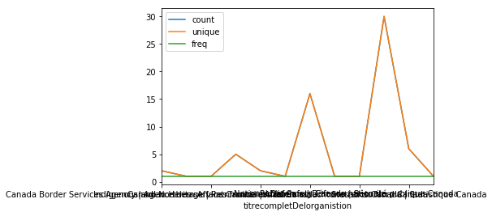

```python
acces[(asexual1|asexual2|asexual3|asexual4)].groupby("titrecompletDelorganistion").resume_fr.describe().plot(kind='line')
```

*Tentative de création d'un graphique à partir des données obtenues à la question 3.*</I>

|  | dataFor | total |
| --- | --- | --- |
| 0 | Agence des services frontaliers du Canada | 2 |
| 1 | Agence du revenu du Canada | 1 |
| 2 | Patrimoine canadien | 1 |
| 3 | Ministère de la Justice | 5 |
| 4 | Affaires autochtones et du Nord Canada | 2 |
| 5 | Innovation, Sciences et Développement économiq... | 1 |
| 6 | Défense nationale | 16 |
| 7 | Commission des libérations conditionnelles du... | 1 |
| 8 | Sécurité publique Canada | 1 |
| 9 | Gendarmerie royale du Canada | 30 |
| 10 | Statistique Canada | 6 |
| 11 | Condition féminine Canada | 1 |

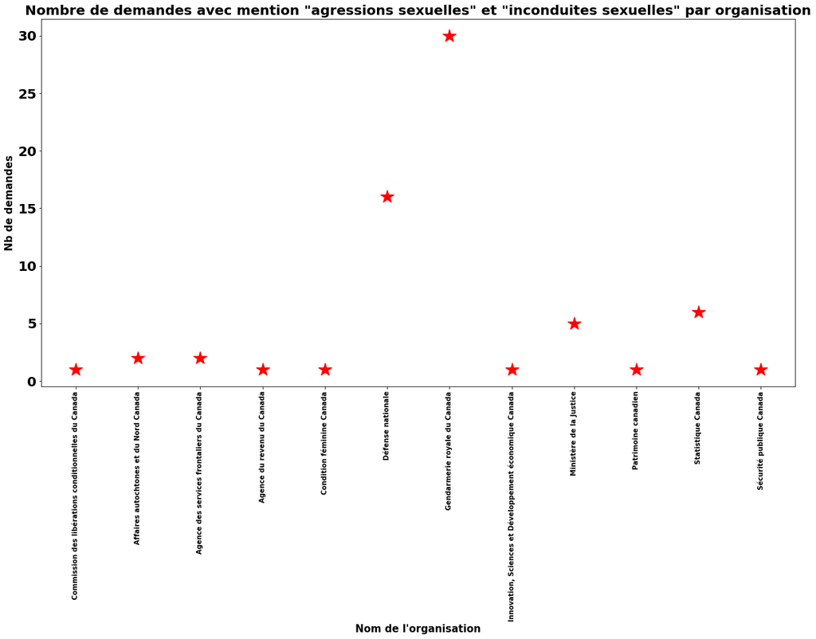

```python
graphique = pan.DataFrame(columns=['dataFor','total'])
graphique['dataFor'] = [("Agence des services frontaliers du Canada"),("Agence du revenu du Canada"),("Patrimoine canadien"),("Ministère de la Justice"),("Affaires autochtones et du Nord Canada"),("Innovation, Sciences et Développement économique Canada"),("Défense nationale"),(" Commission des libérations conditionnelles du Canada"),("Sécurité publique Canada"),("Gendarmerie royale du Canada"),("Statistique Canada"),("Condition féminine Canada")]
graphique['total'] = [2,1,1,5,2,1,16,1,1,30,6,1]

plt.figure(figsize=(20,10))
#plt.plot(graphique.dataFor, graphique.total, linewidth=5)
plt.plot(graphique.dataFor,graphique.total, '*', linewidth=5, markersize=20, color='red')
plt.xticks(fontsize=10, fontweight='bold',rotation=90)
plt.yticks(fontsize=20, fontweight='bold')
plt.xlabel("Nom de l'organisation", fontsize=15, fontweight='bold')
plt.ylabel('Nb de demandes',fontsize=15, fontweight='bold')
plt.title('Nombre de demandes avec mention "agressions sexuelles" et "inconduites sexuelles" par organisation',fontsize=20, fontweight='bold')
#plt.tight_layout()

graphique
```